# Assignment 1

Review the scenario.

Our team needs to explore GP appointment records. The NHS must balance its infrastructure and staffing capacity against patient demand, understand missed appointment trends, and gauge whether external signals like Twitter/X can provide additional insight. Stakeholders are divided, some call for expanded capacity, others for better utilisation of existing resources.

Summarise the business questions.

1. Has there been adequate staff and capacity in the GP networks to meet appointment demand?
2. What is the actual utilisation of GP resources like appointment durations and wait times?
3. How have missed appointments varied over time, region and appointment mode, and how did data capture issues like June–November 2018 affect these rates?
4. Can sentiment from Twitter/X help explain patterns in attendance or capacity strain?

Plan your initial analytic approach.

Capacity vs. Demand: We’ll use the appointments_regional.csv to count how many appointment slots were offered by region, month, and mode and compare that to how many were actually booked and attended. We’ll also use the monthly coverage data which is the number of practices included vs. total practices to adjust for missing reporting. By calculating the ratio of booked slots to available slots over time and by region, we can spot where and when capacity falls short.

Resource Utilisation: From actual_duration.csv, we’ll clean the actual_duration values and from appointments_regional.csv we’ll get wait times which is the days between the booking and appointment. We’ll then find summary statistics like the average, median, and distribution and create boxplots to see how long appointments take and how long patients wait, broken down by appointment mode and region.

Missed Appointments (DNA): Using appointments_regional.csv, we’ll filter the appointment_status column to get counts of ‘Did Not Attend’ (DNA) and ‘Attended’. We’ll calculate the DNA rate as DNA ÷ (Attended + DNA) for each region and month. We’ll plot this over time, paying special attention to the June–November 2018 period when DNA counts were under reported.

External Signals (Twitter/X): We’ll load tweets.csv and extract relevant hashtags and keywords. Then we’ll count tweets and run a simple sentiment score per week or month. By overlaying these social media trends on our DNA and capacity plots, we can see if spikes in frustration or discussions like #GP, #healthcare align with appointment outcomes.

# Assignment 2

```python
import pandas as pd
import numpy as np

import warnings
warnings.filterwarnings('ignore')
```

```python
ad = pd.read_csv('actual_duration.csv')
ar = pd.read_csv('appointments_regional.csv')
nc = pd.read_excel('national_categories.xlsx')
```

```python
print(ad.shape)
print(ar.shape)
print(nc.shape)
```

```
(137793, 8)
(596821, 7)
(817394, 8)
```

```python
print(ad.dtypes)
print(ar.dtypes)
print(nc.dtypes)
```

```
sub_icb_location_code        object
sub_icb_location_ons_code    object
sub_icb_location_name        object
icb_ons_code                 object
region_ons_code              object
appointment_date             object
actual_duration              object
count_of_appointments         int64
dtype: object
icb_ons_code                         object
appointment_month                    object
appointment_status                   object
hcp_type                             object
appointment_mode                     object
time_between_book_and_appointment    object
count_of_appointments                 int64
dtype: object
appointment_date         datetime64[ns]
icb_ons_code                     object
sub_icb_location_name            object
service_setting                  object
context_type                     object
national_category                object
count_of_appointments             int64
appointment_month                object
dtype: object
```

```python
print(ad.columns)
print(ar.columns)
print(nc.columns)
```

```
Index(['sub_icb_location_code', 'sub_icb_location_ons_code',
       'sub_icb_location_name', 'icb_ons_code', 'region_ons_code',
       'appointment_date', 'actual_duration', 'count_of_appointments'],
      dtype='object')
Index(['icb_ons_code', 'appointment_month', 'appointment_status', 'hcp_type',
       'appointment_mode', 'time_between_book_and_appointment',
       'count_of_appointments'],
      dtype='object')
Index(['appointment_date', 'icb_ons_code', 'sub_icb_location_name',
       'service_setting', 'context_type', 'national_category',
       'count_of_appointments', 'appointment_month'],
      dtype='object')
```

```python
ad.describe()
```

|  | count_of_appointments |
| --- | --- |
| count | 137793.000000 |
| mean | 1219.080011 |
| std | 1546.902956 |
| min | 1.000000 |
| 25% | 194.000000 |
| 50% | 696.000000 |
| 75% | 1621.000000 |
| max | 15400.000000 |

```python
ar.describe()
```

|  | count_of_appointments |
| --- | --- |
| count | 596821.000000 |
| mean | 1244.601857 |
| std | 5856.887042 |
| min | 1.000000 |
| 25% | 7.000000 |
| 50% | 47.000000 |
| 75% | 308.000000 |
| max | 211265.000000 |

```python
nc.describe()
```

|  | appointment_date | count_of_appointments |
| --- | --- | --- |
| count | 817394 | 817394.000000 |
| mean | 2022-01-16 00:50:35.860796160 | 362.183684 |
| min | 2021-08-01 00:00:00 | 1.000000 |
| 25% | 2021-10-25 00:00:00 | 7.000000 |
| 50% | 2022-01-18 00:00:00 | 25.000000 |
| 75% | 2022-04-07 00:00:00 | 128.000000 |
| max | 2022-06-30 00:00:00 | 16590.000000 |
| std | NaN | 1084.576600 |

```python
ad.info()
```

```
<class 'pandas.core.frame.DataFrame'>
RangeIndex: 137793 entries, 0 to 137792
Data columns (total 8 columns):
 #   Column                     Non-Null Count   Dtype
---  ------                     --------------   -----
 0   sub_icb_location_code      137793 non-null  object
 1   sub_icb_location_ons_code  137793 non-null  object
 2   sub_icb_location_name      137793 non-null  object
 3   icb_ons_code               137793 non-null  object
 4   region_ons_code            137793 non-null  object
 5   appointment_date           137793 non-null  object
 6   actual_duration            137793 non-null  object
 7   count_of_appointments      137793 non-null  int64
dtypes: int64(1), object(7)
memory usage: 8.4+ MB
```

```python
ar.info()
```

```
<class 'pandas.core.frame.DataFrame'>
RangeIndex: 596821 entries, 0 to 596820
Data columns (total 7 columns):
 #   Column                             Non-Null Count   Dtype
---  ------                             --------------   -----
 0   icb_ons_code                       596821 non-null  object
 1   appointment_month                  596821 non-null  object
 2   appointment_status                 596821 non-null  object
 3   hcp_type                           596821 non-null  object
 4   appointment_mode                   596821 non-null  object
 5   time_between_book_and_appointment  596821 non-null  object
 6   count_of_appointments              596821 non-null  int64
dtypes: int64(1), object(6)
memory usage: 31.9+ MB
```

```python
nc.info()
```

```
<class 'pandas.core.frame.DataFrame'>
RangeIndex: 817394 entries, 0 to 817393
Data columns (total 8 columns):
 #   Column                 Non-Null Count   Dtype
---  ------                 --------------   -----
 0   appointment_date       817394 non-null  datetime64[ns]
 1   icb_ons_code           817394 non-null  object
 2   sub_icb_location_name  817394 non-null  object
 3   service_setting        817394 non-null  object
 4   context_type           817394 non-null  object
 5   national_category      817394 non-null  object
 6   count_of_appointments  817394 non-null  int64
 7   appointment_month      817394 non-null  object
dtypes: datetime64[ns](1), int64(1), object(6)
memory usage: 49.9+ MB
```

```python
ad
```

|  | sub_icb_location_code | sub_icb_location_ons_code | sub_icb_location_name | icb_ons_code | region_ons_code | appointment_date | actual_duration | count_of_appointments |
| --- | --- | --- | --- | --- | --- | --- | --- | --- |
| 0 | 00L | E38000130 | NHS North East and North Cumbria ICB - 00L | E54000050 | E40000012 | 01-Dec-21 | 31-60 Minutes | 364 |
| 1 | 00L | E38000130 | NHS North East and North Cumbria ICB - 00L | E54000050 | E40000012 | 01-Dec-21 | 21-30 Minutes | 619 |
| 2 | 00L | E38000130 | NHS North East and North Cumbria ICB - 00L | E54000050 | E40000012 | 01-Dec-21 | 6-10 Minutes | 1698 |
| 3 | 00L | E38000130 | NHS North East and North Cumbria ICB - 00L | E54000050 | E40000012 | 01-Dec-21 | Unknown / Data Quality | 1277 |
| 4 | 00L | E38000130 | NHS North East and North Cumbria ICB - 00L | E54000050 | E40000012 | 01-Dec-21 | 16-20 Minutes | 730 |
| ... | ... | ... | ... | ... | ... | ... | ... | ... |
| 137788 | X2C4Y | E38000254 | NHS West Yorkshire ICB - X2C4Y | E54000054 | E40000012 | 30-Jun-22 | 31-60 Minutes | 430 |
| 137789 | X2C4Y | E38000254 | NHS West Yorkshire ICB - X2C4Y | E54000054 | E40000012 | 30-Jun-22 | 21-30 Minutes | 751 |
| 137790 | X2C4Y | E38000254 | NHS West Yorkshire ICB - X2C4Y | E54000054 | E40000012 | 30-Jun-22 | 16-20 Minutes | 921 |
| 137791 | X2C4Y | E38000254 | NHS West Yorkshire ICB - X2C4Y | E54000054 | E40000012 | 30-Jun-22 | 11-15 Minutes | 1439 |
| 137792 | X2C4Y | E38000254 | NHS West Yorkshire ICB - X2C4Y | E54000054 | E40000012 | 30-Jun-22 | 1-5 Minutes | 1739 |

137793 rows × 8 columns

```python
ar
```

|  | icb_ons_code | appointment_month | appointment_status | hcp_type | appointment_mode | time_between_book_and_appointment | count_of_appointments |
| --- | --- | --- | --- | --- | --- | --- | --- |
| 0 | E54000034 | 2020-01 | Attended | GP | Face-to-Face | 1 Day | 8107 |
| 1 | E54000034 | 2020-01 | Attended | GP | Face-to-Face | 15 to 21 Days | 6791 |
| 2 | E54000034 | 2020-01 | Attended | GP | Face-to-Face | 2 to 7 Days | 20686 |
| 3 | E54000034 | 2020-01 | Attended | GP | Face-to-Face | 22 to 28 Days | 4268 |
| 4 | E54000034 | 2020-01 | Attended | GP | Face-to-Face | 8 to 14 Days | 11971 |
| ... | ... | ... | ... | ... | ... | ... | ... |
| 596816 | E54000050 | 2022-06 | Unknown | Unknown | Unknown | 2 to 7 Days | 21 |
| 596817 | E54000050 | 2022-06 | Unknown | Unknown | Unknown | 22 to 28 Days | 8 |
| 596818 | E54000050 | 2022-06 | Unknown | Unknown | Unknown | 8 to 14 Days | 28 |
| 596819 | E54000050 | 2022-06 | Unknown | Unknown | Unknown | More than 28 Days | 17 |
| 596820 | E54000050 | 2022-06 | Unknown | Unknown | Unknown | Same Day | 10 |

596821 rows × 7 columns

```python
nc
```

|  | appointment_date | icb_ons_code | sub_icb_location_name | service_setting | context_type | national_category | count_of_appointments | appointment_month |
| --- | --- | --- | --- | --- | --- | --- | --- | --- |
| 0 | 2021-08-02 | E54000050 | NHS North East and North Cumbria ICB - 00L | Primary Care Network | Care Related Encounter | Patient contact during Care Home Round | 3 | 2021-08 |
| 1 | 2021-08-02 | E54000050 | NHS North East and North Cumbria ICB - 00L | Other | Care Related Encounter | Planned Clinics | 7 | 2021-08 |
| 2 | 2021-08-02 | E54000050 | NHS North East and North Cumbria ICB - 00L | General Practice | Care Related Encounter | Home Visit | 79 | 2021-08 |
| 3 | 2021-08-02 | E54000050 | NHS North East and North Cumbria ICB - 00L | General Practice | Care Related Encounter | General Consultation Acute | 725 | 2021-08 |
| 4 | 2021-08-02 | E54000050 | NHS North East and North Cumbria ICB - 00L | General Practice | Care Related Encounter | Structured Medication Review | 2 | 2021-08 |
| ... | ... | ... | ... | ... | ... | ... | ... | ... |
| 817389 | 2022-06-30 | E54000054 | NHS West Yorkshire ICB - X2C4Y | Extended Access Provision | Care Related Encounter | Unplanned Clinical Activity | 12 | 2022-06 |
| 817390 | 2022-06-30 | E54000054 | NHS West Yorkshire ICB - X2C4Y | Extended Access Provision | Care Related Encounter | Planned Clinics | 4 | 2022-06 |
| 817391 | 2022-06-30 | E54000054 | NHS West Yorkshire ICB - X2C4Y | Extended Access Provision | Care Related Encounter | Planned Clinical Procedure | 92 | 2022-06 |
| 817392 | 2022-06-30 | E54000054 | NHS West Yorkshire ICB - X2C4Y | Extended Access Provision | Care Related Encounter | General Consultation Routine | 4 | 2022-06 |
| 817393 | 2022-06-30 | E54000054 | NHS West Yorkshire ICB - X2C4Y | Extended Access Provision | Care Related Encounter | General Consultation Acute | 19 | 2022-06 |

817394 rows × 8 columns

```python
print(ad.isnull().sum())
```

```
sub_icb_location_code        0
sub_icb_location_ons_code    0
sub_icb_location_name        0
icb_ons_code                 0
region_ons_code              0
appointment_date             0
actual_duration              0
count_of_appointments        0
dtype: int64
```

```python
print(ar.isnull().sum())
```

```
icb_ons_code                         0
appointment_month                    0
appointment_status                   0
hcp_type                             0
appointment_mode                     0
time_between_book_and_appointment    0
count_of_appointments                0
dtype: int64
```

```python
print(nc.isnull().sum())
```

```
appointment_date         0
icb_ons_code             0
sub_icb_location_name    0
service_setting          0
context_type             0
national_category        0
count_of_appointments    0
appointment_month        0
dtype: int64
```

```python
count_of_locations = nc['sub_icb_location_name'].value_counts()

count_of_locations
```

```
sub_icb_location_name
NHS North West London ICB - W2U3Z              13007
NHS Kent and Medway ICB - 91Q                  12637
NHS Devon ICB - 15N                            12526
NHS Hampshire and Isle Of Wight ICB - D9Y0V    12171
NHS North East London ICB - A3A8R              11837
                                               ...
NHS North East and North Cumbria ICB - 00N      4210
NHS Lancashire and South Cumbria ICB - 02G      4169
NHS Cheshire and Merseyside ICB - 01V           3496
NHS Cheshire and Merseyside ICB - 01T           3242
NHS Greater Manchester ICB - 00V                2170
Name: count, Length: 106, dtype: int64
```

```python
count_of_locations = nc['sub_icb_location_name'].count()

count_of_locations
```

```
817394
```

```python
list_of_locations = nc['sub_icb_location_name'].drop_duplicates()

for loc in list_of_locations:
    print(loc)
```

```
NHS North East and North Cumbria ICB - 00L
NHS North East and North Cumbria ICB - 00N
NHS North East and North Cumbria ICB - 00P
NHS Lancashire and South Cumbria ICB - 00Q
NHS Lancashire and South Cumbria ICB - 00R
NHS Greater Manchester ICB - 00T
NHS Greater Manchester ICB - 00V
NHS Lancashire and South Cumbria ICB - 00X
NHS Greater Manchester ICB - 00Y
NHS Lancashire and South Cumbria ICB - 01A
NHS Greater Manchester ICB - 01D
NHS Lancashire and South Cumbria ICB - 01E
NHS Cheshire and Merseyside ICB - 01F
NHS Greater Manchester ICB - 01G
NHS North East and North Cumbria ICB - 01H
NHS Cheshire and Merseyside ICB - 01J
NHS Lancashire and South Cumbria ICB - 01K
NHS Cheshire and Merseyside ICB - 01T
NHS Cheshire and Merseyside ICB - 01V
NHS Greater Manchester ICB - 01W
NHS Cheshire and Merseyside ICB - 01X
NHS Greater Manchester ICB - 01Y
NHS Greater Manchester ICB - 02A
NHS Cheshire and Merseyside ICB - 02E
NHS Lancashire and South Cumbria ICB - 02G
NHS Greater Manchester ICB - 02H
NHS Lancashire and South Cumbria ICB - 02M
NHS South Yorkshire ICB - 02P
NHS Nottingham and Nottinghamshire ICB - 02Q
NHS West Yorkshire ICB - 02T
NHS South Yorkshire ICB - 02X
NHS Humber and North Yorkshire ICB - 02Y
NHS Humber and North Yorkshire ICB - 03F
NHS Humber and North Yorkshire ICB - 03H
NHS Humber and North Yorkshire ICB - 03K
NHS South Yorkshire ICB - 03L
NHS South Yorkshire ICB - 03N
NHS Humber and North Yorkshire ICB - 03Q
NHS West Yorkshire ICB - 03R
NHS Leicester Leicestershire and Rutland ICB - 03W
```

[output cut: 51 more lines]

```
NHS Sussex ICB - 97R
NHS Cheshire and Merseyside ICB - 99A
NHS North East and North Cumbria ICB - 99C
NHS Mid and South Essex ICB - 99E
NHS Mid and South Essex ICB - 99F
NHS Mid and South Essex ICB - 99G
NHS North East London ICB - A3A8R
NHS Coventry and Warwickshire ICB - B2M3M
NHS Black Country ICB - D2P2L
NHS Frimley ICB - D4U1Y
NHS Hampshire and Isle Of Wight ICB - D9Y0V
NHS Bedfordshire Luton and Milton Keynes ICB - M1J4Y
NHS Shropshire Telford and Wrekin ICB - M2L0M
NHS North West London ICB - W2U3Z
NHS West Yorkshire ICB - X2C4Y
```

```python
num_of_locations = len(list_of_locations)

num_of_locations
```

```
106
```

```python
appt = (nc.groupby('sub_icb_location_name')['count_of_appointments'].sum())

top5 = appt.sort_values(ascending=False)

top5.head()
```

```
sub_icb_location_name
NHS North West London ICB - W2U3Z              12142390
NHS North East London ICB - A3A8R               9588891
NHS Kent and Medway ICB - 91Q                   9286167
NHS Hampshire and Isle Of Wight ICB - D9Y0V     8288102
NHS South East London ICB - 72Q                 7850170
Name: count_of_appointments, dtype: int64
```

```python
ss = nc['service_setting'].value_counts()

ss
```

```
service_setting
General Practice             359274
Primary Care Network         183790
Other                        138789
Extended Access Provision    108122
Unmapped                      27419
Name: count, dtype: int64
```

```python
ct = nc['context_type'].value_counts()

ct
```

```
context_type
Care Related Encounter    700481
Inconsistent Mapping       89494
Unmapped                   27419
Name: count, dtype: int64
```

```python
nc2 = nc['national_category'].value_counts()

nc2
```

```
national_category
Inconsistent Mapping                                                   89494
General Consultation Routine                                           89329
General Consultation Acute                                             84874
Planned Clinics                                                        76429
Clinical Triage                                                        74539
Planned Clinical Procedure                                             59631
Structured Medication Review                                           44467
Service provided by organisation external to the practice              43095
Home Visit                                                             41850
Unplanned Clinical Activity                                            40415
Patient contact during Care Home Round                                 28795
Unmapped                                                               27419
Care Home Visit                                                        26644
Social Prescribing Service                                             26492
Care Home Needs Assessment & Personalised Care and Support Planning    23505
Non-contractual chargeable work                                        20896
Walk-in                                                                14179
Group Consultation and Group Education                                  5341
Name: count, dtype: int64
```

```python
ast = nc2 = ar['appointment_status'].value_counts()

ast
```

```
appointment_status
Attended    232137
Unknown     201324
DNA         163360
Name: count, dtype: int64
```

# 1. How many locations are there in the data set?

106

# 2. What are the five locations with the highest number of appointments?

NHS North West London ICB - W2U3Z 12142390 NHS North East London ICB - A3A8R 9588891 NHS Kent and Medway ICB - 91Q 9286167 NHS Hampshire and Isle Of Wight ICB - D9Y0V 8288102 NHS South East London ICB - 72Q 7850170

# 3. How many service settings, context types, national categories, and appointment statuses are there?

service_setting

General Practice 359274 Primary Care Network 183790 Other 138789 Extended Access Provision 108122 Unmapped 27419

context_type

Care Related Encounter 700481 Inconsistent Mapping 89494 Unmapped 27419

national_category

Inconsistent Mapping 89494 General Consultation Routine 89329 General Consultation Acute 84874 Planned Clinics 76429 Clinical Triage 74539 Planned Clinical Procedure 59631 Structured Medication Review 44467 Service provided by organisation external to the practice 43095 Home Visit 41850 Unplanned Clinical Activity 40415 Patient contact during Care Home Round 28795 Unmapped 27419 Care Home Visit 26644 Social Prescribing Service 26492 Care Home Needs Assessment & Personalised Care and Support Planning 23505 Non-contractual chargeable work 20896 Walk-in 14179 Group Consultation and Group Education 5341

appointment_status

Attended 232137 Unknown 201324 DNA 163360

# 1. actual_duration.csv

Data quality & stats:

The actual_duration column is stored as text, so we must convert it into numbers.

Once numeric, you’ll see most appointments last 8–12 minutes, with a long tail stretching up to 60 minutes.

Any durations < 1 minute or > 60 minutes are grouped into an “Unknown / Data Quality Issue” category—they’re almost certainly recording errors.

Other columns to watch:

appointment_date: lets you plot daily trends.

sub_icb_location_code / sub_icb_location_name: for regional breakdowns.

# 2. appointments_regional.csv

Data quality & stats:

The appointment_status field covers: Attended, DNA, Unknown. Due to complications between statuses Available, Booked, Cancelled, About 3–6 % become “Unknown” each month.

After July 2019, a growing share of appointment_mode shows up as “Unknown” (because some systems can’t supply mode data).

Other columns to watch:

appointment_month: perfect for clean month‑by‑month trends.

hcp_type: splits GPs from other practice staff (though only “GP” is reliably captured).

time_between_book_and_appointment: how many days patients wait—key for understanding DNAs and capacity strain.

# 3. national_categories.xlsx

Data quality & stats:

context_type (Care Related Encounter, Inconsistent Mapping, Unmapped) and national_category show that 10–15 % of slots end up “Unmapped” or “Inconsistent,” meaning practices haven’t mapped local appointment types cleanly.

service_setting (General Practice, PCN, Extended Access, Other, Unmapped) also has a notable Unmapped bucket where external providers or shared slots aren’t clearly recorded.

Other columns to watch:

service_setting: to compare no‑show rates or durations between GP vs. PCN vs. Extended Access slots.

national_category: to drill into specific clinic types (e.g. “Structured Medication Review” vs. “General Consultation Routine”).

ONS codes (icb_ons_code, region_ons_code): handy for merging in population or socioeconomic data.

# Tip for all three files:

The count_of_appointments column appears everywhere—use it to weight your analyses (e.g., DNA rate = DNA / (count_of_appointments for Attended + DNA)). And don’t forget to filter or flag all those “Unknown” values before drawing conclusions.

# Assignment 3

```python
ad.head()
```

|  | sub_icb_location_code | sub_icb_location_ons_code | sub_icb_location_name | icb_ons_code | region_ons_code | appointment_date | actual_duration | count_of_appointments |
| --- | --- | --- | --- | --- | --- | --- | --- | --- |
| 0 | 00L | E38000130 | NHS North East and North Cumbria ICB - 00L | E54000050 | E40000012 | 01-Dec-21 | 31-60 Minutes | 364 |
| 1 | 00L | E38000130 | NHS North East and North Cumbria ICB - 00L | E54000050 | E40000012 | 01-Dec-21 | 21-30 Minutes | 619 |
| 2 | 00L | E38000130 | NHS North East and North Cumbria ICB - 00L | E54000050 | E40000012 | 01-Dec-21 | 6-10 Minutes | 1698 |
| 3 | 00L | E38000130 | NHS North East and North Cumbria ICB - 00L | E54000050 | E40000012 | 01-Dec-21 | Unknown / Data Quality | 1277 |
| 4 | 00L | E38000130 | NHS North East and North Cumbria ICB - 00L | E54000050 | E40000012 | 01-Dec-21 | 16-20 Minutes | 730 |

```python
print (ad.dtypes)
```

```
sub_icb_location_code        object
sub_icb_location_ons_code    object
sub_icb_location_name        object
icb_ons_code                 object
region_ons_code              object
appointment_date             object
actual_duration              object
count_of_appointments         int64
dtype: object
```

```python
ad['appointment_date'] = pd.to_datetime(ad['appointment_date'])

print(ad.dtypes)
```

```
sub_icb_location_code                object
sub_icb_location_ons_code            object
sub_icb_location_name                object
icb_ons_code                         object
region_ons_code                      object
appointment_date             datetime64[ns]
actual_duration                      object
count_of_appointments                 int64
dtype: object
```

```python
ad.head()
```

|  | sub_icb_location_code | sub_icb_location_ons_code | sub_icb_location_name | icb_ons_code | region_ons_code | appointment_date | actual_duration | count_of_appointments |
| --- | --- | --- | --- | --- | --- | --- | --- | --- |
| 0 | 00L | E38000130 | NHS North East and North Cumbria ICB - 00L | E54000050 | E40000012 | 2021-12-01 | 31-60 Minutes | 364 |
| 1 | 00L | E38000130 | NHS North East and North Cumbria ICB - 00L | E54000050 | E40000012 | 2021-12-01 | 21-30 Minutes | 619 |
| 2 | 00L | E38000130 | NHS North East and North Cumbria ICB - 00L | E54000050 | E40000012 | 2021-12-01 | 6-10 Minutes | 1698 |
| 3 | 00L | E38000130 | NHS North East and North Cumbria ICB - 00L | E54000050 | E40000012 | 2021-12-01 | Unknown / Data Quality | 1277 |
| 4 | 00L | E38000130 | NHS North East and North Cumbria ICB - 00L | E54000050 | E40000012 | 2021-12-01 | 16-20 Minutes | 730 |

```python
nc['appointment_date'] = pd.to_datetime(nc['appointment_date'])

print(nc.dtypes)
```

```
appointment_date         datetime64[ns]
icb_ons_code                     object
sub_icb_location_name            object
service_setting                  object
context_type                     object
national_category                object
count_of_appointments             int64
appointment_month                object
dtype: object
```

```python
nc.head()
```

|  | appointment_date | icb_ons_code | sub_icb_location_name | service_setting | context_type | national_category | count_of_appointments | appointment_month |
| --- | --- | --- | --- | --- | --- | --- | --- | --- |
| 0 | 2021-08-02 | E54000050 | NHS North East and North Cumbria ICB - 00L | Primary Care Network | Care Related Encounter | Patient contact during Care Home Round | 3 | 2021-08 |
| 1 | 2021-08-02 | E54000050 | NHS North East and North Cumbria ICB - 00L | Other | Care Related Encounter | Planned Clinics | 7 | 2021-08 |
| 2 | 2021-08-02 | E54000050 | NHS North East and North Cumbria ICB - 00L | General Practice | Care Related Encounter | Home Visit | 79 | 2021-08 |
| 3 | 2021-08-02 | E54000050 | NHS North East and North Cumbria ICB - 00L | General Practice | Care Related Encounter | General Consultation Acute | 725 | 2021-08 |
| 4 | 2021-08-02 | E54000050 | NHS North East and North Cumbria ICB - 00L | General Practice | Care Related Encounter | Structured Medication Review | 2 | 2021-08 |

```python
ar['appointment_month'] = pd.to_datetime(ar['appointment_month'])

print(ar.dtypes)
```

```
icb_ons_code                                 object
appointment_month                    datetime64[ns]
appointment_status                           object
hcp_type                                     object
appointment_mode                             object
time_between_book_and_appointment            object
count_of_appointments                         int64
dtype: object
```

```python
ar.head()
```

|  | icb_ons_code | appointment_month | appointment_status | hcp_type | appointment_mode | time_between_book_and_appointment | count_of_appointments |
| --- | --- | --- | --- | --- | --- | --- | --- |
| 0 | E54000034 | 2020-01-01 | Attended | GP | Face-to-Face | 1 Day | 8107 |
| 1 | E54000034 | 2020-01-01 | Attended | GP | Face-to-Face | 15 to 21 Days | 6791 |
| 2 | E54000034 | 2020-01-01 | Attended | GP | Face-to-Face | 2 to 7 Days | 20686 |
| 3 | E54000034 | 2020-01-01 | Attended | GP | Face-to-Face | 22 to 28 Days | 4268 |
| 4 | E54000034 | 2020-01-01 | Attended | GP | Face-to-Face | 8 to 14 Days | 11971 |

```python
min_date_ad = ad['appointment_date'].min()
max_date_ad = ad['appointment_date'].max()

print(min_date_ad)
print(max_date_ad)
```

```
2021-12-01 00:00:00
2022-06-30 00:00:00
```

```python
min_date_nc = nc['appointment_date'].min()
max_date_nc = nc['appointment_date'].max()

print(min_date_nc)
print(max_date_nc)
```

```
2021-08-01 00:00:00
2022-06-30 00:00:00
```

```python
nc_subset = nc[(nc['icb_ons_code'] == 'E54000027')
&(nc['appointment_date'] >= '2022-01-01')
&(nc['appointment_date'] <= '2022-06-01')]

nc_subset.head()
```

|  | appointment_date | icb_ons_code | sub_icb_location_name | service_setting | context_type | national_category | count_of_appointments | appointment_month |
| --- | --- | --- | --- | --- | --- | --- | --- | --- |
| 800289 | 2022-01-01 | E54000027 | NHS North West London ICB - W2U3Z | Unmapped | Unmapped | Unmapped | 496 | 2022-01 |
| 800290 | 2022-01-01 | E54000027 | NHS North West London ICB - W2U3Z | Primary Care Network | Care Related Encounter | Clinical Triage | 19 | 2022-01 |
| 800291 | 2022-01-01 | E54000027 | NHS North West London ICB - W2U3Z | Other | Inconsistent Mapping | Inconsistent Mapping | 1 | 2022-01 |
| 800292 | 2022-01-01 | E54000027 | NHS North West London ICB - W2U3Z | General Practice | Inconsistent Mapping | Inconsistent Mapping | 16 | 2022-01 |
| 800293 | 2022-01-01 | E54000027 | NHS North West London ICB - W2U3Z | Primary Care Network | Care Related Encounter | Planned Clinics | 29 | 2022-01 |

```python
service_setting = nc_subset['service_setting'].value_counts()

service_setting
```

```
service_setting
General Practice             2104
Other                        1318
Primary Care Network         1272
Extended Access Provision    1090
Unmapped                      152
Name: count, dtype: int64
```

```python
nc['appointment_date'] = pd.to_datetime(nc['appointment_date'], errors='coerce')

monthly_summary = (nc.groupby([nc['appointment_date'].dt.year.rename('year'),
        nc['appointment_date'].dt.month.rename('month')])['count_of_appointments'].sum().reset_index(name='monthly_total'))

monthly_summary_sorted = monthly_summary.sort_values(by='monthly_total',ascending=False)

monthly_summary_sorted
```

|  | year | month | monthly_total |
| --- | --- | --- | --- |
| 3 | 2021 | 11 | 30405070 |
| 2 | 2021 | 10 | 30303834 |
| 7 | 2022 | 3 | 29595038 |
| 1 | 2021 | 9 | 28522501 |
| 9 | 2022 | 5 | 27495508 |
| 10 | 2022 | 6 | 25828078 |
| 5 | 2022 | 1 | 25635474 |
| 6 | 2022 | 2 | 25355260 |
| 4 | 2021 | 12 | 25140776 |
| 8 | 2022 | 4 | 23913060 |
| 0 | 2021 | 8 | 23852171 |

```python
ad['month'] = pd.to_datetime(ad['appointment_date']).dt.to_period('M')
ar['month'] = pd.to_datetime(ar['appointment_month'], format='%Y-%m').dt.to_period('M')
nc['month'] = pd.to_datetime(nc['appointment_month'], format='%Y-%m').dt.to_period('M')

ad_counts = ad.groupby('month').size().rename('actual_duration_records')
ar_counts = ar.groupby('month').size().rename('appointments_regional_records')
nc_counts = nc.groupby('month').size().rename('national_categories_records')

monthly_record_counts = pd.concat([ad_counts, ar_counts, nc_counts], axis=1).fillna(0).astype(int)

monthly_record_counts
```

| month | actual_duration_records | appointments_regional_records | national_categories_records |
| --- | --- | --- | --- |
| 2021-12 | 19507 | 20393 | 72651 |
| 2022-01 | 19643 | 20225 | 71896 |
| 2022-02 | 18974 | 20133 | 71769 |
| 2022-03 | 21236 | 20532 | 82822 |
| 2022-04 | 19078 | 20073 | 70012 |
| 2022-05 | 20128 | 20276 | 77425 |
| 2022-06 | 19227 | 20231 | 74168 |
| 2020-01 | 0 | 20889 | 0 |
| 2020-02 | 0 | 20689 | 0 |
| 2020-03 | 0 | 21350 | 0 |
| 2020-04 | 0 | 19124 | 0 |
| 2020-05 | 0 | 18338 | 0 |
| 2020-06 | 0 | 18844 | 0 |
| 2020-07 | 0 | 19502 | 0 |
| 2020-08 | 0 | 19247 | 0 |
| 2020-09 | 0 | 20043 | 0 |
| 2020-10 | 0 | 20122 | 0 |
| 2020-11 | 0 | 19675 | 0 |
| 2020-12 | 0 | 19394 | 0 |
| 2021-01 | 0 | 19319 | 0 |
| 2021-02 | 0 | 18949 | 0 |
| 2021-03 | 0 | 19369 | 0 |
| 2021-04 | 0 | 19452 | 0 |
| 2021-05 | 0 | 19384 | 0 |
| 2021-06 | 0 | 19814 | 0 |
| 2021-07 | 0 | 19899 | 0 |
| 2021-08 | 0 | 19786 | 69999 |
| 2021-09 | 0 | 20441 | 74922 |
| 2021-10 | 0 | 20562 | 74078 |
| 2021-11 | 0 | 20766 | 77652 |

```python
monthly_record_counts = monthly_record_counts.sort_index()

monthly_record_counts['total_all_sources'] = (monthly_record_counts.sum(axis=1))

print(monthly_record_counts['total_all_sources'])
```

```
month
2020-01     20889
2020-02     20689
2020-03     21350
2020-04     19124
2020-05     18338
2020-06     18844
2020-07     19502
2020-08     19247
2020-09     20043
2020-10     20122
2020-11     19675
2020-12     19394
2021-01     19319
2021-02     18949
2021-03     19369
2021-04     19452
2021-05     19384
2021-06     19814
2021-07     19899
2021-08     89785
2021-09     95363
2021-10     94640
2021-11     98418
2021-12    112551
2022-01    111764
2022-02    110876
2022-03    124590
2022-04    109163
2022-05    117829
2022-06    113626
Freq: M, Name: total_all_sources, dtype: int64
```

# Question 1 Between what dates were appointments scheduled?

earliest date: 2021-08-01 latest date: 2022-06-30

# Question 2 Which service setting reported the most appointments in North West London from 1 January to 1 June 2022?

# Question 3 Which month had the highest number of appointments?

year: 2021 month: November monthly total: 30,405,070

# Question 4 What was the total number of records per month?

# Question 5 Summarise and explain how you arrived at the answers to the four questions and what, if any, further questions arose in the process.

Question 3: Month with Highest Appointments Answer: November 2021 (30,405,070 appointments) Convert nc['appointment_month'] to a pandas Period or datetime. Group by that month and sum across count_of_appointments. Sort the results descending and take the first row.

Further Questions That Arose Data‐range alignment: Given that the actual_duration data only begins in December 2021, how should we handle any analysis that needs to join it with the other tables which extend back to January 2020? Seasonal patterns: With the full 30‑month span in ar, do winter months consistently under‑ or over‑perform? Under‑capture impact: How exactly did the June–Nov 2018 DNA under‑reporting affect long‑term DNA rate trends? External correlation: Can peaks in appointment demand or no‑shows be matched to spikes in social‑media sentiment?

# Assignment 4

```python
import pandas as pd
import numpy as np
import matplotlib.pyplot as plt
```

```python
ad = pd.read_csv('actual_duration.csv')
ar = pd.read_csv('appointments_regional.csv')
nc = pd.read_excel('national_categories.xlsx')
```

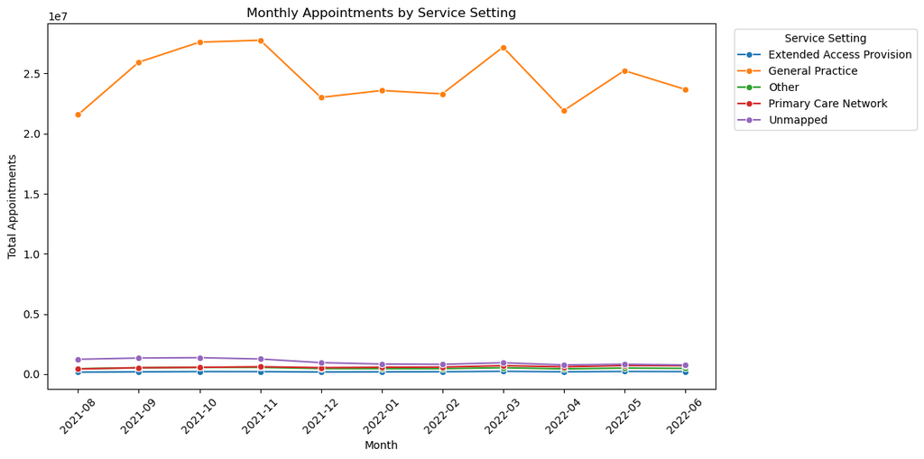

```python
nc['month_str'] = pd.to_datetime(nc['appointment_month'], format='%Y-%m') \
                    .dt.strftime('%Y-%m')

nc_ss = (
    nc
    .groupby(['month_str', 'service_setting'])['count_of_appointments']
    .sum()
    .reset_index()
)

plt.figure(figsize=(12, 6))
sns.lineplot(
    data=nc_ss,
    x='month_str', y='count_of_appointments',
    hue='service_setting', marker='o', errorbar=None
)
plt.xticks(rotation=45)
plt.title('Monthly Appointments by Service Setting')
plt.xlabel('Month')
plt.ylabel('Total Appointments')
plt.legend(title='Service Setting', bbox_to_anchor=(1.02, 1), loc='upper left')
plt.tight_layout()
plt.savefig('nc_ss.png', dpi=300)
plt.show()
```

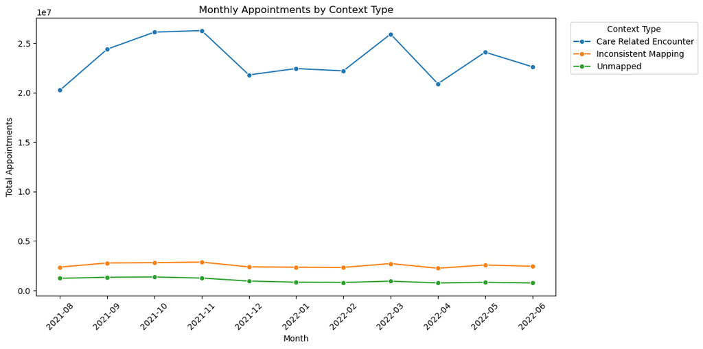

```python
nc_ct = (
    nc
    .groupby(['month_str', 'context_type'])['count_of_appointments']
    .sum()
    .reset_index()
)

plt.figure(figsize=(12, 6))
sns.lineplot(
    data=nc_ct,
    x='month_str', y='count_of_appointments',
    hue='context_type', marker='o', errorbar=None
)
plt.xticks(rotation=45)
plt.title('Monthly Appointments by Context Type')
plt.xlabel('Month')
plt.ylabel('Total Appointments')
plt.legend(title='Context Type', bbox_to_anchor=(1.02, 1), loc='upper left')
plt.tight_layout()
plt.savefig('nc_ct.png', dpi=300)
plt.show()
```

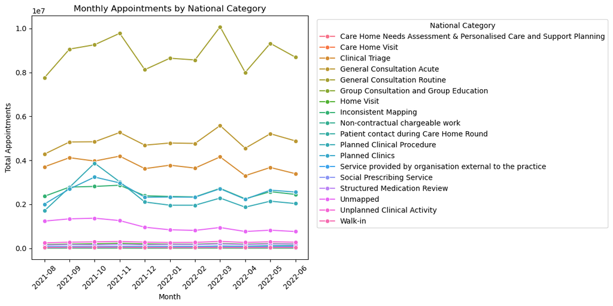

```python
nc_nc = (
    nc
    .groupby(['month_str', 'national_category'])['count_of_appointments']
    .sum()
    .reset_index()
)

plt.figure(figsize=(12, 6))
sns.lineplot(
    data=nc_nc,
    x='month_str', y='count_of_appointments',
    hue='national_category', marker='o', errorbar=None
)
plt.xticks(rotation=45)
plt.title('Monthly Appointments by National Category')
plt.xlabel('Month')
plt.ylabel('Total Appointments')
plt.legend(title='National Category', bbox_to_anchor=(1.02, 1), loc='upper left')
plt.tight_layout()
plt.savefig('nc_nc.png', dpi=300)
plt.show()
```

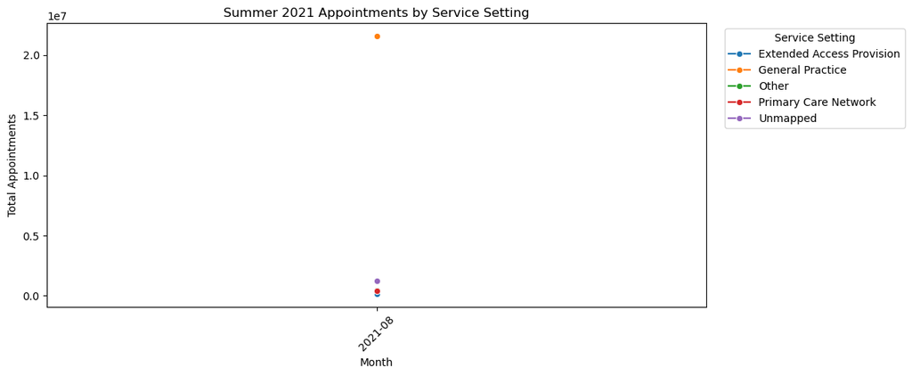

```python
nc['month_str'] = pd.to_datetime(nc['appointment_month'], format='%Y-%m') \
                    .dt.strftime('%Y-%m')

seasons = {
    'Summer 2021': ['2021-06', '2021-07', '2021-08'],
}

for season_name, months in seasons.items():
    df_season = nc[nc['month_str'].isin(months)]

    nc_ss_season = (
        df_season
        .groupby(['month_str', 'service_setting'])['count_of_appointments']
        .sum()
        .reset_index()
    )

    plt.figure(figsize=(12, 5))
    sns.lineplot(
        data=nc_ss_season,
        x='month_str', y='count_of_appointments',
        hue='service_setting',
        marker='o',
        errorbar=None
    )
    plt.title(f'{season_name} Appointments by Service Setting')
    plt.xlabel('Month')
    plt.ylabel('Total Appointments')
    plt.xticks(rotation=45)
    plt.legend(title='Service Setting', bbox_to_anchor=(1.02,1), loc='upper left')
    plt.tight_layout()
    plt.savefig('summer21.png', dpi=300)
    plt.show()
```

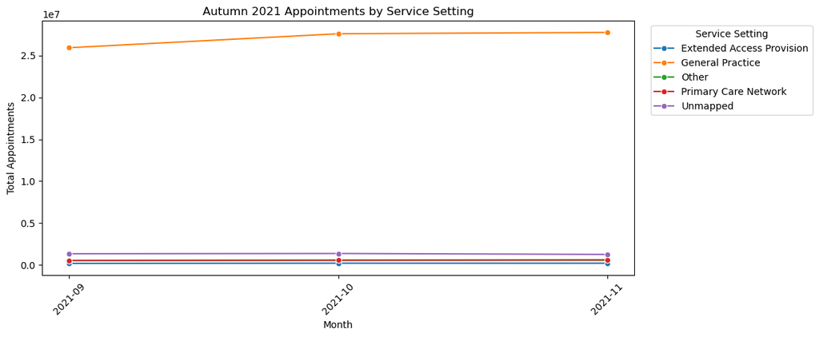

```python
nc['month_str'] = pd.to_datetime(nc['appointment_month'], format='%Y-%m') \
                    .dt.strftime('%Y-%m')

seasons = {
    'Autumn 2021': ['2021-09', '2021-10', '2021-11'],
}

for season_name, months in seasons.items():
    df_season = nc[nc['month_str'].isin(months)]

    nc_ss_season = (
        df_season
        .groupby(['month_str', 'service_setting'])['count_of_appointments']
        .sum()
        .reset_index()
    )

    plt.figure(figsize=(12, 5))
    sns.lineplot(
        data=nc_ss_season,
        x='month_str', y='count_of_appointments',
        hue='service_setting',
        marker='o',
        errorbar=None
    )
    plt.title(f'{season_name} Appointments by Service Setting')
    plt.xlabel('Month')
    plt.ylabel('Total Appointments')
    plt.xticks(rotation=45)
    plt.legend(title='Service Setting', bbox_to_anchor=(1.02,1), loc='upper left')
    plt.tight_layout()
    plt.savefig('autumn21.png', dpi=300)
    plt.show()
```

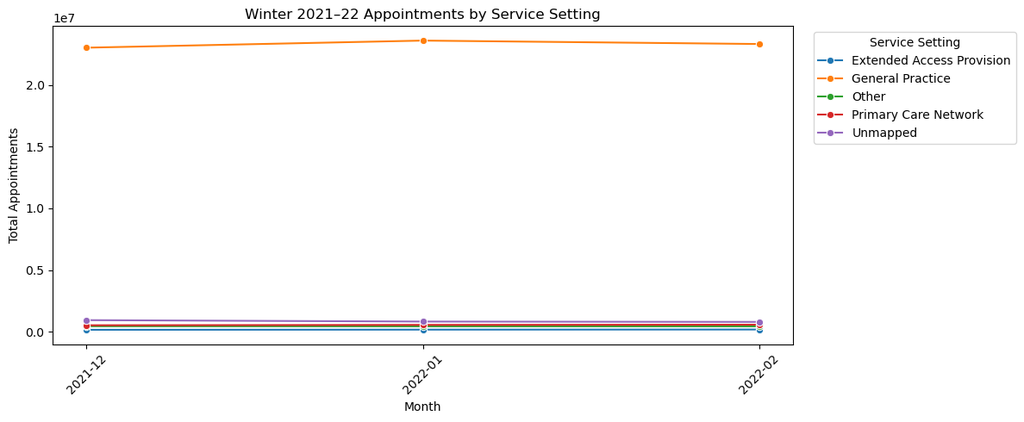

```python
nc['month_str'] = pd.to_datetime(nc['appointment_month'], format='%Y-%m') \
                    .dt.strftime('%Y-%m')

seasons = {
    'Winter 2021–22': ['2021-12', '2022-01', '2022-02'],
}

for season_name, months in seasons.items():
    df_season = nc[nc['month_str'].isin(months)]

    nc_ss_season = (
        df_season
        .groupby(['month_str', 'service_setting'])['count_of_appointments']
        .sum()
        .reset_index()
    )

    plt.figure(figsize=(12, 5))
    sns.lineplot(
        data=nc_ss_season,
        x='month_str', y='count_of_appointments',
        hue='service_setting',
        marker='o',
        errorbar=None
    )
    plt.title(f'{season_name} Appointments by Service Setting')
    plt.xlabel('Month')
    plt.ylabel('Total Appointments')
    plt.xticks(rotation=45)
    plt.legend(title='Service Setting', bbox_to_anchor=(1.02,1), loc='upper left')
    plt.tight_layout()
    plt.savefig('winter21_22.png', dpi=300)
    plt.show()
```

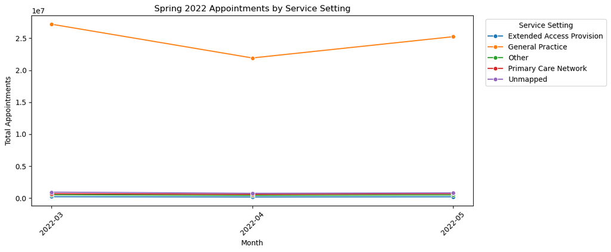

```python
nc['month_str'] = pd.to_datetime(nc['appointment_month'], format='%Y-%m') \
                    .dt.strftime('%Y-%m')

seasons = {
    'Spring 2022': ['2022-03', '2022-04', '2022-05'],
}

for season_name, months in seasons.items():
    df_season = nc[nc['month_str'].isin(months)]

    nc_ss_season = (
        df_season
        .groupby(['month_str', 'service_setting'])['count_of_appointments']
        .sum()
        .reset_index()
    )

    plt.figure(figsize=(12, 5))
    sns.lineplot(
        data=nc_ss_season,
        x='month_str', y='count_of_appointments',
        hue='service_setting',
        marker='o',
        errorbar=None
    )
    plt.title(f'{season_name} Appointments by Service Setting')
    plt.xlabel('Month')
    plt.ylabel('Total Appointments')
    plt.xticks(rotation=45)
    plt.legend(title='Service Setting', bbox_to_anchor=(1.02,1), loc='upper left')
    plt.tight_layout()
    plt.savefig('spring_22.png', dpi=300)
    plt.show()
```

# Summarise and explain any trends you've identified for both aggregated monthly and seasonal visualisations.

Range & Peaks/Troughs: Total appointments by month (across all service settings) vary from roughly 23.8 million (Aug 2021) up to 30.4 million (Nov 2021). The top three months are November 2021 (≈30.4 M), October 2021 (≈30.3 M), and March 2022 (≈29.6 M). The lowest points occur in August 2021 (≈23.85 M) and April 2022 (≈23.91 M). Underlying Drivers The October–November 2021 surge likely reflects ramped-up routine care after the summer lull and the end of the school holidays. The March 2022 peak comes just before Easter—clinics push to clear backlogs before the holiday. Summer slowdown (July/August) and Easter trough (April) are the two clearest “dip” periods.

Implications Staffing & Resources should flex up in October–November and again in March, then plan for lower capacity in summer months and Easter. Backlog management: anticipate spikes just before holiday dips and schedule catch-up slots post-holiday (May/January). Predictable seasonality can inform appointment-booking windows, supply ordering, and patient-communication campaigns to smooth demand.

# Assignment 5

```python
import pandas as pd
import seaborn as sns

# Set figure size.
sns.set(rc={'figure.figsize':(15, 12)})

# Set the plot style as white.
sns.set_style('white')

# Maximum column width to display
pd.options.display.max_colwidth = 200
```

```python
tweets = pd.read_csv('tweets.csv')
```

```python
tweets.head()
```

|  | tweet_id | tweet_full_text | tweet_entities | tweet_entities_hashtags | tweet_metadata | tweet_retweet_count | tweet_favorite_count | tweet_favorited | tweet_retweeted | tweet_lang |
| --- | --- | --- | --- | --- | --- | --- | --- | --- | --- | --- |
| 0 | 1567629223795527681 | As Arkansas’ first Comprehensive Stroke Certified Center, UAMS provides Arkansans with access to the most advanced stoke care. Join us in our mission to make a difference in the health and well-be... | {'hashtags': [{'text': 'Healthcare', 'indices': [253, 264]}], 'symbols': [], 'user_mentions': [], 'urls': [{'url': 'https://t.co/yw0cstfmSI', 'expanded_url': 'https://bit.ly/3BiSKbs', 'display_url... | #Healthcare | {'iso_language_code': 'en', 'result_type': 'recent'} | 0 | 0 | False | False | en |
| 1 | 1567582846612553728 | RT @AndreaGrammer: Work-life balance is at the foundation of how decisions are made and where #PremiseHealth is headed. We're #hiring for… | {'hashtags': [{'text': 'PremiseHealth', 'indices': [94, 108]}, {'text': 'hiring', 'indices': [127, 134]}], 'symbols': [], 'user_mentions': [{'screen_name': 'AndreaGrammer', 'name': 'Andrea Grammer... | #PremiseHealth, #hiring | {'iso_language_code': 'en', 'result_type': 'recent'} | 2 | 0 | False | False | en |
| 2 | 1567582787070304256 | RT @OntarioGreens: $10 billion can go a long way to fixing our broken #Healthcare system.\n\nYet Doug Ford would rather spend it ALL on a hig… | {'hashtags': [{'text': 'Healthcare', 'indices': [70, 81]}], 'symbols': [], 'user_mentions': [{'screen_name': 'OntarioGreens', 'name': 'Green Party of Ontario', 'id': 37115912, 'id_str': '37115912'... | #Healthcare | {'iso_language_code': 'en', 'result_type': 'recent'} | 39 | 0 | False | False | en |
| 3 | 1567582767625428992 | RT @modrnhealthcr: 🚨#NEW:🚨 Insurance companies are figuring out the best ways to collect information about members’ race and ethnicity data… | {'hashtags': [{'text': 'NEW', 'indices': [20, 24]}], 'symbols': [], 'user_mentions': [{'screen_name': 'modrnhealthcr', 'name': 'Modern Healthcare', 'id': 18935711, 'id_str': '18935711', 'indices':... | #NEW | {'iso_language_code': 'en', 'result_type': 'recent'} | 5 | 0 | False | False | en |
| 4 | 1567582720460570625 | ICYMI: Our recent blogs on Cybersecurity in Accounting https://t.co/4nnK0FiVVL and Digital Transformation in Healthcare Finance https://t.co/jIqn52lHD3 are a great read, take a look!\n\n#blogs #di... | {'hashtags': [{'text': 'blogs', 'indices': [184, 190]}, {'text': 'digitaltransformation', 'indices': [191, 213]}, {'text': 'cybersecurity', 'indices': [214, 228]}, {'text': 'accounting', 'indices'... | #blogs, #digitaltransformation, #cybersecurity, #accounting, #finance, #healthcare | {'iso_language_code': 'en', 'result_type': 'recent'} | 0 | 0 | False | False | en |

```python
tweets.describe
```

[output not shown]

[output cut: 77 more lines]

```python
tweets.info
```

[output not shown]

[output cut: 77 more lines]

```python
print(tweets['tweet_retweet_count'].value_counts().sort_index())
```

```
tweet_retweet_count
0      526
1      215
2      114
3       70
4       27
5       35
6       12
7       18
8       15
9       13
10       5
11       6
12      16
13       1
```

[output cut: 34 more lines]

```python
print(tweets['tweet_favorite_count'].value_counts().sort_index())
```

```
tweet_favorite_count
0     1027
1       91
2       16
3       13
4        7
5        5
6        2
7        1
8        1
9        1
10       1
11       1
12       1
13       1
14       1
17       1
18       1
20       1
28       1
42       1
Name: count, dtype: int64
```

```python
tweets_text = tweets[['tweet_full_text']]

tweets_text
```

|  | tweet_full_text |
| --- | --- |
| 0 | As Arkansas’ first Comprehensive Stroke Certified Center, UAMS provides Arkansans with access to the most advanced stoke care. Join us in our mission to make a difference in the health and well-be... |
| 1 | RT @AndreaGrammer: Work-life balance is at the foundation of how decisions are made and where #PremiseHealth is headed. We're #hiring for… |
| 2 | RT @OntarioGreens: $10 billion can go a long way to fixing our broken #Healthcare system.\n\nYet Doug Ford would rather spend it ALL on a hig… |
| 3 | RT @modrnhealthcr: 🚨#NEW:🚨 Insurance companies are figuring out the best ways to collect information about members’ race and ethnicity data… |
| 4 | ICYMI: Our recent blogs on Cybersecurity in Accounting https://t.co/4nnK0FiVVL and Digital Transformation in Healthcare Finance https://t.co/jIqn52lHD3 are a great read, take a look!\n\n#blogs #di... |
| ... | ... |
| 1169 | RT @PotomacPhotonic: Potomac #Innovation Report: #precisionFabrication techniques Optimize #Microfluidic Mixing of Viscous Fluids \n\n#manuf… |
| 1170 | Not a cent towards workers who would like to advance their training, especially those already employed by SHA or who for various reasons cannot obtain a student loan. Half of our department applie... |
| 1171 | The @hfmaorg Region 9 presents "The Value of ESG to the Healthcare Industry" and our own Kris Russell and Ron Present will be the key speakers. This #webinar will be taking place 9/13 and will exp... |
| 1172 | Happy physiotherapy 🩺 day 🎉..\n#bpt #physiotherapy \n#HealthyNation #healthcare \n#medicalcare \n#csjmu .\n@WHO \n@MoHFW_INDIA \n@nitish_0210 https://t.co/NQHdIoYymC |
| 1173 | RT @KimcoStaffing: Apply now to work for #MediQuestStaffing as EVS - #Hospital - 1st #shift - Interviewing Now!! (#NewportBeach) #job http… |

1174 rows × 1 columns

```python
tags = []
for text in tweets['tweet_full_text'].dropna().values:
    for token in text.split():
        if '#' in token:
            cleaned = re.match(r'#\w+', token.lower())
            if cleaned:
                tags.append(cleaned.group())
```

```python
hashtag_series = pd.Series(tags, name='hashtag')
hashtag_counts = hashtag_series.value_counts()
top30 = hashtag_counts.head(30)

top30
```

```
hashtag
#healthcare                 841
#health                      88
#ai                          47
#medicine                    42
#job                         38
#medical                     35
#strategy                    31
#digitalhealth               31
#pharmaceutical              28
#medtwitter                  27
#pharma                      25
#biotech                     25
#marketing                   25
#competitiveintelligence     25
#meded                       24
#telehealth                  22
#covid                       21
#tipsfornewdocs              21
#hiring                      21
#machinelearning             18
#technology                  18
#healthtech                  18
#vaccine                     18
#news                        17
#medicare                    17
#coronavirus                 16
#womeninmedicine             16
#competitivemarketing        16
#covid19                     15
#wellness                    15
Name: count, dtype: int64
```

```python
hashtag_series = pd.Series(tags, name='hashtag')
data = hashtag_series.value_counts().reset_index()
data.columns = ['word', 'count']
data['count'] = data['count'].astype(int)
```

```python
data.head()
```

|  | word | count |
| --- | --- | --- |
| 0 | #healthcare | 841 |
| 1 | #health | 88 |
| 2 | #ai | 47 |
| 3 | #medicine | 42 |
| 4 | #job | 38 |

```python
data.dtypes
```

```
word     object
count     int32
dtype: object
```

```python
data.describe
```

```
<bound method NDFrame.describe of                word  count
0       #healthcare    841
1           #health     88
2               #ai     47
3         #medicine     42
4              #job     38
...             ...    ...
1529   #savinglives      1
1530  #futureishere      1
1531    #treatments      1
1532   #flexibility      1
1533         #csjmu      1

[1534 rows x 2 columns]>
```

```python
df_top = data[data['count'] > 10].sort_values('count', ascending=False)

df_top
```

|  | word | count |
| --- | --- | --- |
| 0 | #healthcare | 841 |
| 1 | #health | 88 |
| 2 | #ai | 47 |
| 3 | #medicine | 42 |
| 4 | #job | 38 |
| 5 | #medical | 35 |
| 6 | #strategy | 31 |
| 7 | #digitalhealth | 31 |
| 8 | #pharmaceutical | 28 |
| 9 | #medtwitter | 27 |
| 12 | #marketing | 25 |
| 13 | #competitiveintelligence | 25 |
| 11 | #biotech | 25 |
| 10 | #pharma | 25 |
| 14 | #meded | 24 |
| 15 | #telehealth | 22 |
| 16 | #covid | 21 |
| 17 | #tipsfornewdocs | 21 |
| 18 | #hiring | 21 |
| 19 | #machinelearning | 18 |
| 20 | #technology | 18 |
| 21 | #healthtech | 18 |
| 22 | #vaccine | 18 |
| 24 | #medicare | 17 |
| 23 | #news | 17 |
| 26 | #womeninmedicine | 16 |
| 27 | #competitivemarketing | 16 |
| 25 | #coronavirus | 16 |
| 28 | #covid19 | 15 |
| 29 | #wellness | 15 |
| 30 | #tech | 15 |
| 31 | #science | 14 |
| 32 | #doctorofveterinarymedicine | 14 |
| 33 | #telemedicine | 14 |
| 34 | #education | 14 |
| 37 | #nursing | 13 |
| 38 | #foamed | 13 |
| 36 | #mentalhealth | 13 |
| 35 | #patientcare | 13 |
| 39 | #doctor | 12 |
| 40 | #hospitals | 12 |
| 41 | #nurses | 12 |
| 42 | #data | 12 |
| 43 | #medtech | 11 |
| 44 | #python | 11 |
| 45 | #healthcareit | 11 |
| 46 | #digitaltransformation | 11 |
| 47 | #usa | 11 |
| 48 | #innovation | 11 |

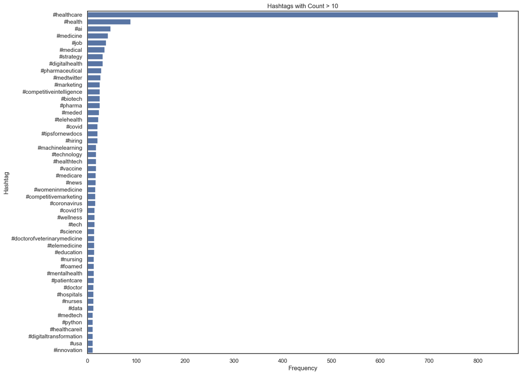

```python
plt.figure()
sns.barplot(
    data=df_top,
    x='count',
    y='word',
)
plt.title("Hashtags with Count > 10")
plt.xlabel("Frequency")
plt.ylabel("Hashtag")

plt.show()
```

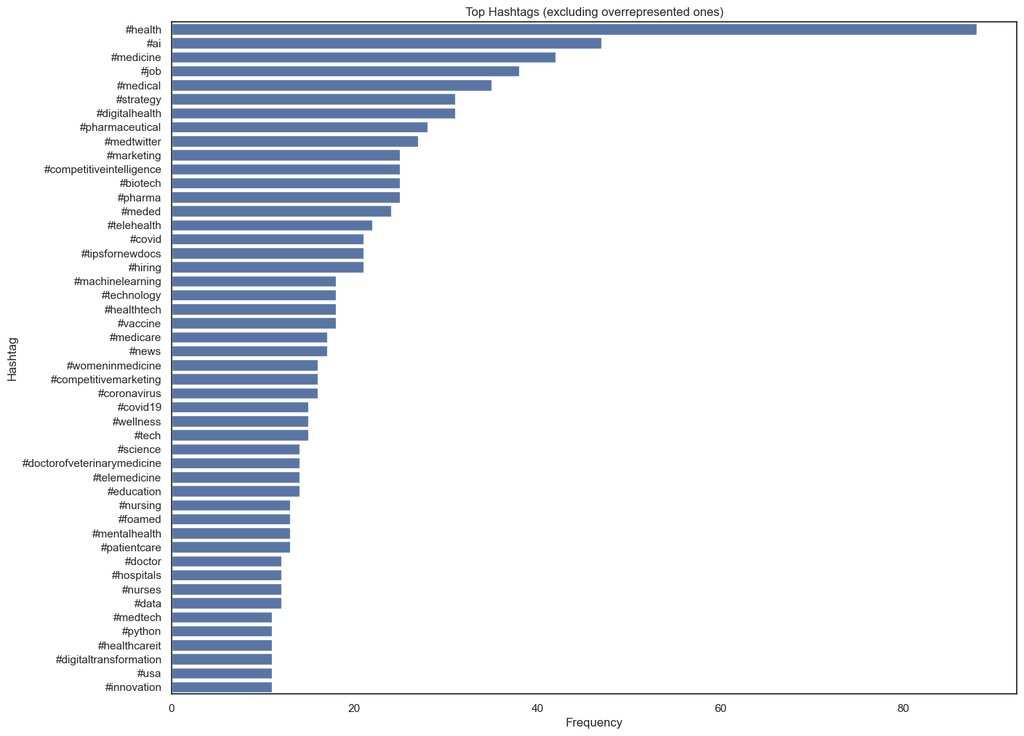

```python
filtered = df_top.drop(df_top.index[0])

plt.figure()
sns.barplot(
    data=filtered,
    x='count',
    y='word',
)
plt.title("Top Hashtags (excluding overrepresented ones)")
plt.xlabel("Frequency")
plt.ylabel("Hashtag")

plt.show()
```

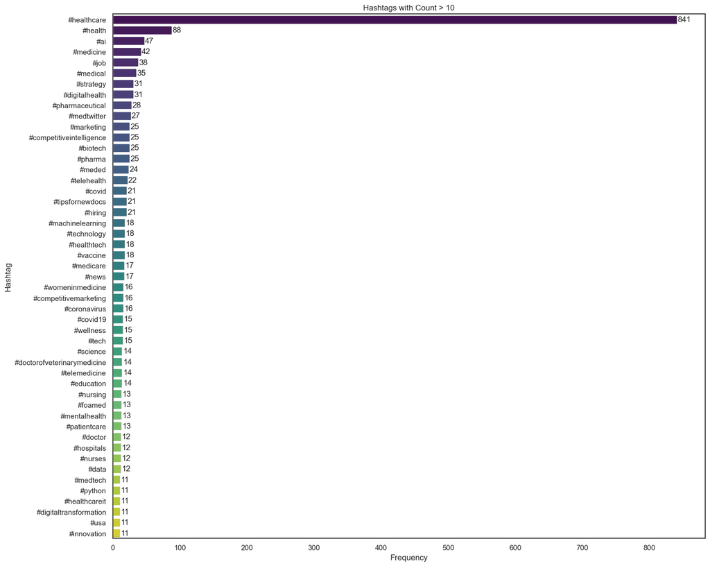

```python
plt.figure()
sns.barplot(
    data=df_top,
    x='count',
    y='word',
    palette='viridis',
    errorbar=None
)
plt.title("Hashtags with Count > 10")
plt.xlabel("Frequency")
plt.ylabel("Hashtag")
plt.tight_layout()

for i, row in enumerate(df_top.itertuples()):
    plt.text(row.count + 1, i, f"{row.count}", va='center')
plt.show()
```

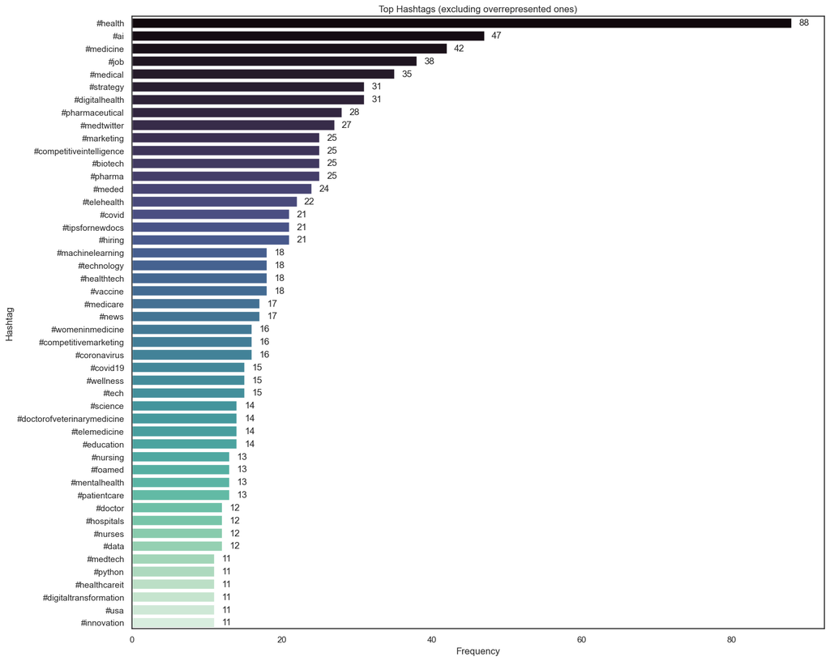

```python
plt.figure()
sns.barplot(
    data=filtered,
    x='count',
    y='word',
    palette='mako',
    errorbar=None
)
plt.title("Top Hashtags (excluding overrepresented ones)")
plt.xlabel("Frequency")
plt.ylabel("Hashtag")
plt.tight_layout()

for i, row in enumerate(filtered.itertuples()):
    plt.text(row.count + 1, i, f"{row.count}", va='center')
plt.show()
```

# Do you think it is useful to look at these columns in more detail?

The tweet_retweet_count and tweet_favorite_count columns measure engagement—how widely a tweet was amplified or liked. Their value counts and summary statistics reveal a highly skewed distribution: most tweets have low or zero engagement, while a small number have very high counts. Visualising on a log scale helps expose the long tail without those few popular tweets dominating the view.

It is useful to inspect these columns further because:

High-engagement tweets (high retweets/favorites) likely carry outsized influence and could be weighted more heavily when surfacing trending topics or validating sentiment.

Outliers (very large counts) may point to viral content or key influencers.

However, relying solely on high-engagement tweets risks missing emerging themes present in lower-visibility tweets, so a balanced approach (e.g., all hashtags but annotated or weighted by engagement) is preferable.

# 1. How your team can use tweets to provide feedback to stakeholders

Show what people are talking about in real time. Collect and summarise the top hashtags and recurring keywords so stakeholders see current public concerns (e.g., about booking, waiting times, missed appointments). Measure sentiment and engagement. Use likes and retweets to surface which topics resonate most high engagement tweets signal issues or messages that need attention. Track trends and spikes. Visualise increases in certain themes like sudden rise in complaints about capacity so stakeholders can act quickly. Provide “voice of the public” examples. Include anonymysed representative sample tweets to give colour and context behind the numbers, this turns abstract metrics into relatable feedback. Close the loop with communication. Use Twitter not just to listen but to respond or clarify on things like public updates, and then report back to stakeholders on how messaging changed perception.

# 2. Do the tweets add value to the overall project?

Yes. Tweets add external, real-time context that internal data alone may miss. They surface unsolicited patient sentiment, complaints, praise, or confusion, helping validate or explain patterns seen in appointment data. They act as an early warning system for emerging problems like sudden negative chatter about access issues, so the NHS can investigate before issues escalate. They help prioritise actions by showing which topics have the most public attention via hashtag frequency and engagement. I believe the value is greatest when tweets are treated as a complementary signal, not the sole source because social media can be noisy and skewed.

# 3. How the NHS can utilise tweets

Monitor public sentiment around service availability, capacity, and patient experience to inform operational decisions. Run and coordinate campaigns using official hashtags to encourage behaviours like reminders, vaccination drives, appointment booking guides. Respond to misinformation or confusion quickly by seeing what questions or myths are circulating and correcting them publicly. Amplify positive stories or successful initiatives to build trust and awareness. Engage directly with users for basic service support or guidance and then feed those interaction insights back to planners.

# 4. Suggestions to improve future data collection or analysis

Define clear goals and key topics to track like “missed appointments” or “wait times” so the hashtag keyword extraction is focused. Capture engagement metrics like likes and retweets alongside raw tweet text to help weight importance. Aggregate and visualise trends over time to distinguish noise from sustained issues. For example compare daily and weekly volume of a hashtag. Use consistent, official hashtags in NHS messaging to make tracking easier and reduce fragmentation. Combine listening with response. track the impact of public replies or campaigns to close the feedback loop.

# Assignment 6

```python
import pandas as pd

ar = pd.read_csv('appointments_regional.csv')

ar['appointment_month'] = pd.to_datetime(ar['appointment_month'], format='%Y-%m')

print("First five rows of ar:")
print(ar.head(), "\n")

min_date = ar['appointment_month'].min().date()
max_date = ar['appointment_month'].max().date()
print(f"Date range in ar: {min_date} → {max_date}\n")

ar_filt = ar[ar['appointment_month'] >= '2021-08-01'].copy()

print("Filtered rows (from 2021-08 onward):")
print(ar_filt.head())
```

```
First five rows of ar:
  icb_ons_code appointment_month appointment_status hcp_type appointment_mode  \
0    E54000034        2020-01-01           Attended       GP     Face-to-Face
1    E54000034        2020-01-01           Attended       GP     Face-to-Face
2    E54000034        2020-01-01           Attended       GP     Face-to-Face
3    E54000034        2020-01-01           Attended       GP     Face-to-Face
4    E54000034        2020-01-01           Attended       GP     Face-to-Face

  time_between_book_and_appointment  count_of_appointments
0                             1 Day                   8107
1                    15  to 21 Days                   6791
2                       2 to 7 Days                  20686
3                    22  to 28 Days                   4268
4                     8  to 14 Days                  11971

Date range in ar: 2020-01-01 → 2022-06-01

Filtered rows (from 2021-08 onward):
     icb_ons_code appointment_month appointment_status hcp_type  \
3652    E54000034        2021-08-01           Attended       GP
3653    E54000034        2021-08-01           Attended       GP
3654    E54000034        2021-08-01           Attended       GP
3655    E54000034        2021-08-01           Attended       GP
3656    E54000034        2021-08-01           Attended       GP

     appointment_mode time_between_book_and_appointment  count_of_appointments
3652     Face-to-Face                             1 Day                   6553
3653     Face-to-Face                    15  to 21 Days                   2390
3654     Face-to-Face                       2 to 7 Days                  10547
3655     Face-to-Face                    22  to 28 Days                    937
3656     Face-to-Face                     8  to 14 Days                   4961
```

```python
import pandas as pd

ar = pd.read_csv('appointments_regional.csv')

ar['appointment_month'] = pd.to_datetime(ar['appointment_month'], format='%Y-%m')

ar.head()
```

|  | icb_ons_code | appointment_month | appointment_status | hcp_type | appointment_mode | time_between_book_and_appointment | count_of_appointments |
| --- | --- | --- | --- | --- | --- | --- | --- |
| 0 | E54000034 | 2020-01-01 | Attended | GP | Face-to-Face | 1 Day | 8107 |
| 1 | E54000034 | 2020-01-01 | Attended | GP | Face-to-Face | 15 to 21 Days | 6791 |
| 2 | E54000034 | 2020-01-01 | Attended | GP | Face-to-Face | 2 to 7 Days | 20686 |
| 3 | E54000034 | 2020-01-01 | Attended | GP | Face-to-Face | 22 to 28 Days | 4268 |
| 4 | E54000034 | 2020-01-01 | Attended | GP | Face-to-Face | 8 to 14 Days | 11971 |

```python
min_date = ar['appointment_month'].min().date()
max_date = ar['appointment_month'].max().date()

min_date
```

```
datetime.date(2020, 1, 1)
```

```python
max_date
```

```
datetime.date(2022, 6, 1)
```

```python
ar_filt = ar[ar['appointment_month'] >= '2021-08-01'].copy()

ar_filt.head()
```

|  | icb_ons_code | appointment_month | appointment_status | hcp_type | appointment_mode | time_between_book_and_appointment | count_of_appointments |
| --- | --- | --- | --- | --- | --- | --- | --- |
| 3652 | E54000034 | 2021-08-01 | Attended | GP | Face-to-Face | 1 Day | 6553 |
| 3653 | E54000034 | 2021-08-01 | Attended | GP | Face-to-Face | 15 to 21 Days | 2390 |
| 3654 | E54000034 | 2021-08-01 | Attended | GP | Face-to-Face | 2 to 7 Days | 10547 |
| 3655 | E54000034 | 2021-08-01 | Attended | GP | Face-to-Face | 22 to 28 Days | 937 |
| 3656 | E54000034 | 2021-08-01 | Attended | GP | Face-to-Face | 8 to 14 Days | 4961 |

```python
ar_agg = (
    ar_filt
    .groupby([
        'appointment_month',
        'hcp_type',
        'appointment_status',
        'appointment_mode',
        'time_between_book_and_appointment'
    ])['count_of_appointments']
    .sum()
    .reset_index()
)

ar_agg
```

|  | appointment_month | hcp_type | appointment_status | appointment_mode | time_between_book_and_appointment | count_of_appointments |
| --- | --- | --- | --- | --- | --- | --- |
| 0 | 2021-08-01 | GP | Attended | Face-to-Face | 1 Day | 507835 |
| 1 | 2021-08-01 | GP | Attended | Face-to-Face | 15 to 21 Days | 194726 |
| 2 | 2021-08-01 | GP | Attended | Face-to-Face | 2 to 7 Days | 959486 |
| 3 | 2021-08-01 | GP | Attended | Face-to-Face | 22 to 28 Days | 102111 |
| 4 | 2021-08-01 | GP | Attended | Face-to-Face | 8 to 14 Days | 398772 |
| ... | ... | ... | ... | ... | ... | ... |
| 3749 | 2022-06-01 | Unknown | Unknown | Unknown | 8 to 14 Days | 5494 |
| 3750 | 2022-06-01 | Unknown | Unknown | Unknown | More than 28 Days | 5115 |
| 3751 | 2022-06-01 | Unknown | Unknown | Unknown | Same Day | 1914 |
| 3752 | 2022-06-01 | Unknown | Unknown | Unknown | Unknown / Data Quality | 53 |
| 3753 | 2022-06-01 | Unknown | Unknown | Video/Online | 2 to 7 Days | 1 |

3754 rows × 6 columns

```python
ar_df = (
    ar_filt
    .groupby('appointment_month')['count_of_appointments']
    .sum()
    .reset_index()
)

ar_df
```

|  | appointment_month | count_of_appointments |
| --- | --- | --- |
| 0 | 2021-08-01 | 23852171 |
| 1 | 2021-09-01 | 28522501 |
| 2 | 2021-10-01 | 30303834 |
| 3 | 2021-11-01 | 30405070 |
| 4 | 2021-12-01 | 25140776 |
| 5 | 2022-01-01 | 25635474 |
| 6 | 2022-02-01 | 25355260 |
| 7 | 2022-03-01 | 29595038 |
| 8 | 2022-04-01 | 23913060 |
| 9 | 2022-05-01 | 27495508 |
| 10 | 2022-06-01 | 25828078 |

```python
ar_df['daily_avg'] = ar_df['count_of_appointments'] / 30

ar_df
```

[output not shown]

```python
ar_df['utilisation'] = ((ar_df['daily_avg'] / 1_200_000) * 100).round(1)

ar_df
```

|  | appointment_month | count_of_appointments | daily_avg | utilisation |
| --- | --- | --- | --- | --- |
| 0 | 2021-08-01 | 23852171 | 7.950724e+05 | 66.3 |
| 1 | 2021-09-01 | 28522501 | 9.507500e+05 | 79.2 |
| 2 | 2021-10-01 | 30303834 | 1.010128e+06 | 84.2 |
| 3 | 2021-11-01 | 30405070 | 1.013502e+06 | 84.5 |
| 4 | 2021-12-01 | 25140776 | 8.380259e+05 | 69.8 |
| 5 | 2022-01-01 | 25635474 | 8.545158e+05 | 71.2 |
| 6 | 2022-02-01 | 25355260 | 8.451753e+05 | 70.4 |
| 7 | 2022-03-01 | 29595038 | 9.865013e+05 | 82.2 |
| 8 | 2022-04-01 | 23913060 | 7.971020e+05 | 66.4 |
| 9 | 2022-05-01 | 27495508 | 9.165169e+05 | 76.4 |
| 10 | 2022-06-01 | 25828078 | 8.609359e+05 | 71.7 |

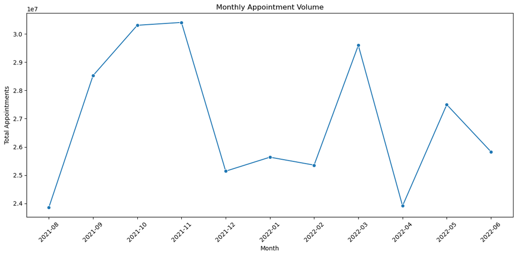

```python
import seaborn as sns
import matplotlib.pyplot as plt

ar_df['month_str'] = ar_df['appointment_month'].dt.strftime('%Y-%m')

plt.figure(figsize=(12, 6))
sns.lineplot(
    data=ar_df,
    x='month_str',
    y='count_of_appointments',
    marker='o',
    errorbar=None
)
plt.title('Monthly Appointment Volume')
plt.xlabel('Month')
plt.ylabel('Total Appointments')
plt.xticks(rotation=45)
plt.tight_layout()
plt.show()
```

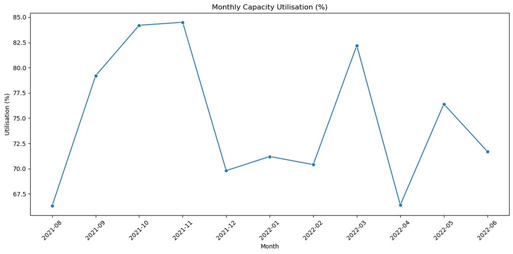

```python
plt.figure(figsize=(12, 6))
sns.lineplot(
    data=ar_df,
    x='month_str',
    y='utilisation',
    marker='o',
    errorbar=None
)
plt.title('Monthly Capacity Utilisation (%)')
plt.xlabel('Month')
plt.ylabel('Utilisation (%)')
plt.xticks(rotation=45)
plt.tight_layout()
plt.show()
```

```python
hcp_trends = (
    ar_filt
    .groupby(['appointment_month', 'hcp_type'])['count_of_appointments']
    .sum()
    .reset_index()
)

hcp_trends
```

|  | appointment_month | hcp_type | count_of_appointments |
| --- | --- | --- | --- |
| 0 | 2021-08-01 | GP | 12299022 |
| 1 | 2021-08-01 | Other Practice staff | 10797821 |
| 2 | 2021-08-01 | Unknown | 755328 |
| 3 | 2021-09-01 | GP | 14487785 |
| 4 | 2021-09-01 | Other Practice staff | 13126731 |
| 5 | 2021-09-01 | Unknown | 907985 |
| 6 | 2021-10-01 | GP | 14300751 |
| 7 | 2021-10-01 | Other Practice staff | 14942504 |
| 8 | 2021-10-01 | Unknown | 1060579 |
| 9 | 2021-11-01 | GP | 14897749 |
| 10 | 2021-11-01 | Other Practice staff | 14432800 |
| 11 | 2021-11-01 | Unknown | 1074521 |
| 12 | 2021-12-01 | GP | 12654767 |
| 13 | 2021-12-01 | Other Practice staff | 11614470 |
| 14 | 2021-12-01 | Unknown | 871539 |
| 15 | 2022-01-01 | GP | 13138050 |
| 16 | 2022-01-01 | Other Practice staff | 11705142 |
| 17 | 2022-01-01 | Unknown | 792282 |
| 18 | 2022-02-01 | GP | 12869711 |
| 19 | 2022-02-01 | Other Practice staff | 11688107 |
| 20 | 2022-02-01 | Unknown | 797442 |
| 21 | 2022-03-01 | GP | 15127227 |
| 22 | 2022-03-01 | Other Practice staff | 13528583 |
| 23 | 2022-03-01 | Unknown | 939228 |
| 24 | 2022-04-01 | GP | 11908463 |
| 25 | 2022-04-01 | Other Practice staff | 11217738 |
| 26 | 2022-04-01 | Unknown | 786859 |
| 27 | 2022-05-01 | GP | 13793934 |
| 28 | 2022-05-01 | Other Practice staff | 12823200 |
| 29 | 2022-05-01 | Unknown | 878374 |
| 30 | 2022-06-01 | GP | 12893983 |
| 31 | 2022-06-01 | Other Practice staff | 12105677 |
| 32 | 2022-06-01 | Unknown | 828418 |

```python
hcp_trends['month_str'] = hcp_trends['appointment_month'].dt.strftime('%Y-%m')

hcp_trends
```

|  | appointment_month | hcp_type | count_of_appointments | month_str |
| --- | --- | --- | --- | --- |
| 0 | 2021-08-01 | GP | 12299022 | 2021-08 |
| 1 | 2021-08-01 | Other Practice staff | 10797821 | 2021-08 |
| 2 | 2021-08-01 | Unknown | 755328 | 2021-08 |
| 3 | 2021-09-01 | GP | 14487785 | 2021-09 |
| 4 | 2021-09-01 | Other Practice staff | 13126731 | 2021-09 |
| 5 | 2021-09-01 | Unknown | 907985 | 2021-09 |
| 6 | 2021-10-01 | GP | 14300751 | 2021-10 |
| 7 | 2021-10-01 | Other Practice staff | 14942504 | 2021-10 |
| 8 | 2021-10-01 | Unknown | 1060579 | 2021-10 |
| 9 | 2021-11-01 | GP | 14897749 | 2021-11 |
| 10 | 2021-11-01 | Other Practice staff | 14432800 | 2021-11 |
| 11 | 2021-11-01 | Unknown | 1074521 | 2021-11 |
| 12 | 2021-12-01 | GP | 12654767 | 2021-12 |
| 13 | 2021-12-01 | Other Practice staff | 11614470 | 2021-12 |
| 14 | 2021-12-01 | Unknown | 871539 | 2021-12 |
| 15 | 2022-01-01 | GP | 13138050 | 2022-01 |
| 16 | 2022-01-01 | Other Practice staff | 11705142 | 2022-01 |
| 17 | 2022-01-01 | Unknown | 792282 | 2022-01 |
| 18 | 2022-02-01 | GP | 12869711 | 2022-02 |
| 19 | 2022-02-01 | Other Practice staff | 11688107 | 2022-02 |
| 20 | 2022-02-01 | Unknown | 797442 | 2022-02 |
| 21 | 2022-03-01 | GP | 15127227 | 2022-03 |
| 22 | 2022-03-01 | Other Practice staff | 13528583 | 2022-03 |
| 23 | 2022-03-01 | Unknown | 939228 | 2022-03 |
| 24 | 2022-04-01 | GP | 11908463 | 2022-04 |
| 25 | 2022-04-01 | Other Practice staff | 11217738 | 2022-04 |
| 26 | 2022-04-01 | Unknown | 786859 | 2022-04 |
| 27 | 2022-05-01 | GP | 13793934 | 2022-05 |
| 28 | 2022-05-01 | Other Practice staff | 12823200 | 2022-05 |
| 29 | 2022-05-01 | Unknown | 878374 | 2022-05 |
| 30 | 2022-06-01 | GP | 12893983 | 2022-06 |
| 31 | 2022-06-01 | Other Practice staff | 12105677 | 2022-06 |
| 32 | 2022-06-01 | Unknown | 828418 | 2022-06 |

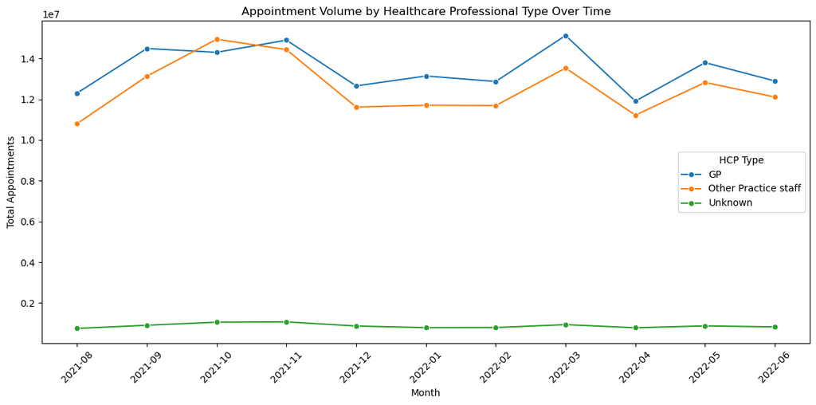

```python
plt.figure(figsize=(12, 6))
sns.lineplot(
    data=hcp_trends,
    x='month_str',
    y='count_of_appointments',
    hue='hcp_type',
    marker='o',
    errorbar=None
)
plt.title('Appointment Volume by Healthcare Professional Type Over Time')
plt.xlabel('Month')
plt.ylabel('Total Appointments')
plt.xticks(rotation=45)
plt.legend(title='HCP Type')
plt.tight_layout()
plt.show()
```

```python
status_trends = (
    ar_filt
    .groupby(['appointment_month', 'appointment_status'])['count_of_appointments']
    .sum()
    .reset_index()
)

status_trends
```

|  | appointment_month | appointment_status | count_of_appointments |
| --- | --- | --- | --- |
| 0 | 2021-08-01 | Attended | 22081765 |
| 1 | 2021-08-01 | DNA | 949137 |
| 2 | 2021-08-01 | Unknown | 821269 |
| 3 | 2021-09-01 | Attended | 25757066 |
| 4 | 2021-09-01 | DNA | 1321348 |
| 5 | 2021-09-01 | Unknown | 1444087 |
| 6 | 2021-10-01 | Attended | 27170506 |
| 7 | 2021-10-01 | DNA | 1565624 |
| 8 | 2021-10-01 | Unknown | 1567704 |
| 9 | 2021-11-01 | Attended | 27667665 |
| 10 | 2021-11-01 | DNA | 1428087 |
| 11 | 2021-11-01 | Unknown | 1309318 |
| 12 | 2021-12-01 | Attended | 22853483 |
| 13 | 2021-12-01 | DNA | 1198866 |
| 14 | 2021-12-01 | Unknown | 1088427 |
| 15 | 2022-01-01 | Attended | 23597196 |
| 16 | 2022-01-01 | DNA | 1076013 |
| 17 | 2022-01-01 | Unknown | 962265 |
| 18 | 2022-02-01 | Attended | 23351939 |
| 19 | 2022-02-01 | DNA | 1076658 |
| 20 | 2022-02-01 | Unknown | 926663 |
| 21 | 2022-03-01 | Attended | 27170002 |
| 22 | 2022-03-01 | DNA | 1289888 |
| 23 | 2022-03-01 | Unknown | 1135148 |
| 24 | 2022-04-01 | Attended | 21948814 |
| 25 | 2022-04-01 | DNA | 1045455 |
| 26 | 2022-04-01 | Unknown | 918791 |
| 27 | 2022-05-01 | Attended | 25343941 |
| 28 | 2022-05-01 | DNA | 1199518 |
| 29 | 2022-05-01 | Unknown | 952049 |
| 30 | 2022-06-01 | Attended | 23715317 |
| 31 | 2022-06-01 | DNA | 1167790 |
| 32 | 2022-06-01 | Unknown | 944971 |

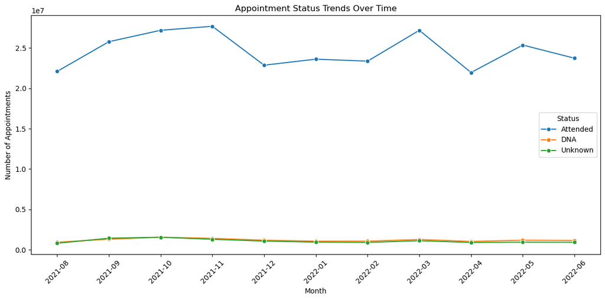

```python
status_trends['month_str'] = status_trends['appointment_month'].dt.strftime('%Y-%m')

plt.figure(figsize=(12, 6))
sns.lineplot(
    data=status_trends,
    x='month_str',
    y='count_of_appointments',
    hue='appointment_status',
    marker='o',
    errorbar=None
)
plt.title('Appointment Status Trends Over Time')
plt.xlabel('Month')
plt.ylabel('Number of Appointments')
plt.xticks(rotation=45)
plt.legend(title='Status')
plt.tight_layout()
plt.show()
```

```python
mode_trends = (
    ar_filt
    .groupby(['appointment_month', 'appointment_mode'])['count_of_appointments']
    .sum()
    .reset_index()
)

mode_trends
```

|  | appointment_month | appointment_mode | count_of_appointments |
| --- | --- | --- | --- |
| 0 | 2021-08-01 | Face-to-Face | 13717325 |
| 1 | 2021-08-01 | Home Visit | 151619 |
| 2 | 2021-08-01 | Telephone | 9149072 |
| 3 | 2021-08-01 | Unknown | 724126 |
| 4 | 2021-08-01 | Video/Online | 110029 |
| 5 | 2021-09-01 | Face-to-Face | 17266602 |
| 6 | 2021-09-01 | Home Visit | 171829 |
| 7 | 2021-09-01 | Telephone | 10068770 |
| 8 | 2021-09-01 | Unknown | 859946 |
| 9 | 2021-09-01 | Video/Online | 155354 |
| 10 | 2021-10-01 | Face-to-Face | 19471561 |
| 11 | 2021-10-01 | Home Visit | 178593 |
| 12 | 2021-10-01 | Telephone | 9449544 |
| 13 | 2021-10-01 | Unknown | 1029671 |
| 14 | 2021-10-01 | Video/Online | 174465 |
| 15 | 2021-11-01 | Face-to-Face | 19031327 |
| 16 | 2021-11-01 | Home Visit | 203352 |
| 17 | 2021-11-01 | Telephone | 9993842 |
| 18 | 2021-11-01 | Unknown | 1015969 |
| 19 | 2021-11-01 | Video/Online | 160580 |
| 20 | 2021-12-01 | Face-to-Face | 15312340 |
| 21 | 2021-12-01 | Home Visit | 181264 |
| 22 | 2021-12-01 | Telephone | 8723325 |
| 23 | 2021-12-01 | Unknown | 798049 |
| 24 | 2021-12-01 | Video/Online | 125798 |
| 25 | 2022-01-01 | Face-to-Face | 15414102 |
| 26 | 2022-01-01 | Home Visit | 171669 |
| 27 | 2022-01-01 | Telephone | 9212553 |
| 28 | 2022-01-01 | Unknown | 706352 |
| 29 | 2022-01-01 | Video/Online | 130798 |
| 30 | 2022-02-01 | Face-to-Face | 15531971 |
| 31 | 2022-02-01 | Home Visit | 170435 |
| 32 | 2022-02-01 | Telephone | 8820538 |
| 33 | 2022-02-01 | Unknown | 704619 |
| 34 | 2022-02-01 | Video/Online | 127697 |
| 35 | 2022-03-01 | Face-to-Face | 18333743 |
| 36 | 2022-03-01 | Home Visit | 200945 |
| 37 | 2022-03-01 | Telephone | 10088419 |
| 38 | 2022-03-01 | Unknown | 819913 |
| 39 | 2022-03-01 | Video/Online | 152018 |
| 40 | 2022-04-01 | Face-to-Face | 15049567 |
| 41 | 2022-04-01 | Home Visit | 172936 |
| 42 | 2022-04-01 | Telephone | 7893805 |
| 43 | 2022-04-01 | Unknown | 670299 |
| 44 | 2022-04-01 | Video/Online | 126453 |
| 45 | 2022-05-01 | Face-to-Face | 17630858 |
| 46 | 2022-05-01 | Home Visit | 200862 |
| 47 | 2022-05-01 | Telephone | 8792743 |
| 48 | 2022-05-01 | Unknown | 726857 |
| 49 | 2022-05-01 | Video/Online | 144188 |
| 50 | 2022-06-01 | Face-to-Face | 16744191 |
| 51 | 2022-06-01 | Home Visit | 187640 |
| 52 | 2022-06-01 | Telephone | 8082270 |
| 53 | 2022-06-01 | Unknown | 677860 |
| 54 | 2022-06-01 | Video/Online | 136117 |

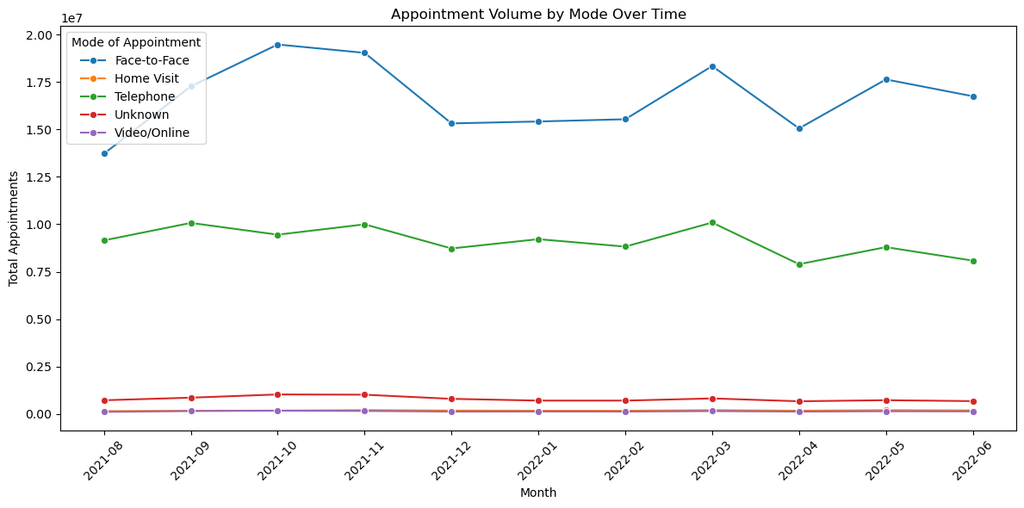

```python
mode_trends['month_str'] = mode_trends['appointment_month'].dt.strftime('%Y-%m')

plt.figure(figsize=(12, 6))
sns.lineplot(
    data=mode_trends,
    x='month_str',
    y='count_of_appointments',
    hue='appointment_mode',
    marker='o',
    errorbar=None
)
plt.title('Appointment Volume by Mode Over Time')
plt.xlabel('Month')
plt.ylabel('Total Appointments')
plt.xticks(rotation=45)
plt.legend(title='Mode of Appointment')
plt.tight_layout()
plt.show()
```

```python
time_trends = (
    ar_filt
    .groupby(['appointment_month', 'time_between_book_and_appointment'])['count_of_appointments']
    .sum()
    .reset_index()
)

time_trends
```

|  | appointment_month | time_between_book_and_appointment | count_of_appointments |
| --- | --- | --- | --- |
| 0 | 2021-08-01 | 1 Day | 2018319 |
| 1 | 2021-08-01 | 15 to 21 Days | 1453209 |
| 2 | 2021-08-01 | 2 to 7 Days | 4924960 |
| 3 | 2021-08-01 | 22 to 28 Days | 828866 |
| 4 | 2021-08-01 | 8 to 14 Days | 2889150 |
| ... | ... | ... | ... |
| 83 | 2022-06-01 | 22 to 28 Days | 1217197 |
| 84 | 2022-06-01 | 8 to 14 Days | 3250347 |
| 85 | 2022-06-01 | More than 28 Days | 1067420 |
| 86 | 2022-06-01 | Same Day | 11461923 |
| 87 | 2022-06-01 | Unknown / Data Quality | 21536 |

88 rows × 3 columns

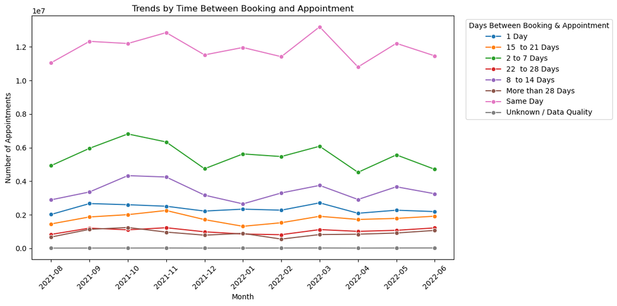

```python
time_trends['month_str'] = time_trends['appointment_month'].dt.strftime('%Y-%m')

plt.figure(figsize=(12, 6))
sns.lineplot(
    data=time_trends,
    x='month_str',
    y='count_of_appointments',
    hue='time_between_book_and_appointment',
    marker='o',
    errorbar=None
)
plt.title('Trends by Time Between Booking and Appointment')
plt.xlabel('Month')
plt.ylabel('Number of Appointments')
plt.xticks(rotation=45)
plt.legend(title='Days Between Booking & Appointment', bbox_to_anchor=(1.02,1), loc='upper left')
plt.tight_layout()
plt.show()
```

```python
nc = pd.read_excel('national_categories.xlsx')

nc_ss = (
    nc
    .groupby(['appointment_month', 'service_setting'])['count_of_appointments']
    .sum()
    .reset_index()
)

nc_ss
```

|  | appointment_month | service_setting | count_of_appointments |
| --- | --- | --- | --- |
| 0 | 2021-08 | Extended Access Provision | 160927 |
| 1 | 2021-08 | General Practice | 21575852 |
| 2 | 2021-08 | Other | 449101 |
| 3 | 2021-08 | Primary Care Network | 432448 |
| 4 | 2021-08 | Unmapped | 1233843 |
| 5 | 2021-09 | Extended Access Provision | 187906 |
| 6 | 2021-09 | General Practice | 25940821 |
| 7 | 2021-09 | Other | 527174 |
| 8 | 2021-09 | Primary Care Network | 530485 |
| 9 | 2021-09 | Unmapped | 1336115 |
| 10 | 2021-10 | Extended Access Provision | 209539 |
| 11 | 2021-10 | General Practice | 27606171 |
| 12 | 2021-10 | Other | 556487 |
| 13 | 2021-10 | Primary Care Network | 564981 |
| 14 | 2021-10 | Unmapped | 1366656 |
| 15 | 2021-11 | Extended Access Provision | 207577 |
| 16 | 2021-11 | General Practice | 27767889 |
| 17 | 2021-11 | Other | 558784 |
| 18 | 2021-11 | Primary Care Network | 614324 |
| 19 | 2021-11 | Unmapped | 1256496 |
| 20 | 2021-12 | Extended Access Provision | 173504 |
| 21 | 2021-12 | General Practice | 23008818 |
| 22 | 2021-12 | Other | 464718 |
| 23 | 2021-12 | Primary Care Network | 539479 |
| 24 | 2021-12 | Unmapped | 954257 |
| 25 | 2022-01 | Extended Access Provision | 186375 |
| 26 | 2022-01 | General Practice | 23583053 |
| 27 | 2022-01 | Other | 457440 |
| 28 | 2022-01 | Primary Care Network | 569044 |
| 29 | 2022-01 | Unmapped | 839562 |
| 30 | 2022-02 | Extended Access Provision | 196627 |
| 31 | 2022-02 | General Practice | 23305934 |
| 32 | 2022-02 | Other | 456153 |
| 33 | 2022-02 | Primary Care Network | 585300 |
| 34 | 2022-02 | Unmapped | 811246 |
| 35 | 2022-03 | Extended Access Provision | 231905 |
| 36 | 2022-03 | General Practice | 27187368 |
| 37 | 2022-03 | Other | 530677 |
| 38 | 2022-03 | Primary Care Network | 702176 |
| 39 | 2022-03 | Unmapped | 942912 |
| 40 | 2022-04 | Extended Access Provision | 192284 |
| 41 | 2022-04 | General Practice | 21916791 |
| 42 | 2022-04 | Other | 437402 |
| 43 | 2022-04 | Primary Care Network | 606270 |
| 44 | 2022-04 | Unmapped | 760313 |
| 45 | 2022-05 | Extended Access Provision | 220511 |
| 46 | 2022-05 | General Practice | 25238620 |
| 47 | 2022-05 | Other | 503327 |
| 48 | 2022-05 | Primary Care Network | 712280 |
| 49 | 2022-05 | Unmapped | 820770 |
| 50 | 2022-06 | Extended Access Provision | 209652 |
| 51 | 2022-06 | General Practice | 23680374 |
| 52 | 2022-06 | Other | 478813 |
| 53 | 2022-06 | Primary Care Network | 700599 |
| 54 | 2022-06 | Unmapped | 758640 |

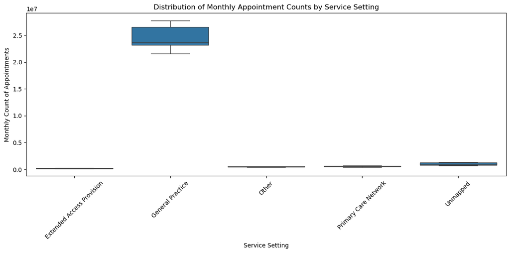

```python
plt.figure(figsize=(12, 6))
sns.boxplot(
    data=nc_ss,
    x='service_setting',
    y='count_of_appointments'
)
plt.title('Distribution of Monthly Appointment Counts by Service Setting')
plt.xlabel('Service Setting')
plt.ylabel('Monthly Count of Appointments')
plt.xticks(rotation=45)
plt.tight_layout()
plt.savefig('ServiceSetting_Boxplot_All.png', dpi=300)
plt.show()
```

```python
nc_no_gp = nc_ss[nc_ss['service_setting'] != 'General Practice']

nc_no_gp
```

[output not shown]

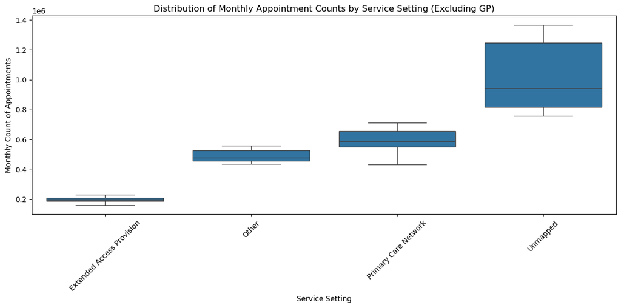

```python
plt.figure(figsize=(12, 6))
sns.boxplot(
    data=nc_ss[nc_ss['service_setting'] != 'General Practice'],
    x='service_setting',
    y='count_of_appointments'
)
plt.title('Distribution of Monthly Appointment Counts by Service Setting (Excluding GP)')
plt.xlabel('Service Setting')
plt.ylabel('Monthly Count of Appointments')
plt.xticks(rotation=45)
plt.tight_layout()
plt.savefig('ServiceSetting_Boxplot_NoGP.png', dpi=300)
plt.show()
```

# Question 1 Should the NHS start looking at increasing staff levels?

Actionable insight: While routine staffing levels appear adequate for the average month, the NHS should consider flexible staffing models (e.g. temporary staff, extended hours, surge teams) to handle those periodic spikes without overworking core staff or compromising patient care.

# Question 2 How do the healthcare professional types differ over time?

Both GP and other‐staff volumes follow the same seasonal pattern. Both peak in October–November 2021 and again around March 2022, then dip over the December–January winter lull and spring.

“Other Practice Staff” play a significant but secondary role. Their total volumes mirror GPs’ rises and falls, suggesting they’re being used in parallel (e.g., triage, minor clinics) when demand surges.

# Question 3 Are there significant changes in whether or not visits are attended?

“Attended” appointments (blue) dominate by a huge margin and follow the same seasonal peaks and dips as overall volume.

“DNA” (Did Not Attend) and “Unknown” (orange & green) both stay very low (around 5 %–6 % of total) and track each other closely.

Proportions remain stable: the ratio of DNAs and “Unknown” to attended barely shifts month-to-month, even during peak demand.

Conclusion: Attendance rates are consistently high, with only a small, stable share of no-shows and unknowns. There’s no large swing in patient non-attendance over the period—so the NHS’s challenges around missed appointments appear to be a persistent, low-level issue rather than one that spikes dramatically in certain months.

# Question 4 Are there changes in terms of appointment type and the busiest months?

Face-to-face dominates: It consistently accounts for the largest share of appointments—peaking around 19–20 million in Oct–Nov 2021 and Mar 2022, and dipping to about 15 million in December 2021 and April 2022.

Telephone is the main remote channel: It runs second, between 8–10 million monthly, mirroring the same peaks and troughs as in-person visits.

Home visits, Video/Online, and Unknown remain very low:

Home visits hover around 100–200 thousand per month.

Video/Online appointments are under 200 thousand, showing limited adoption.

Unknown modes are similarly negligible.

Conclusion: Even during the busiest months, the NHS relies overwhelmingly on face-to-face and telephone appointments. Video/online and home visits play only a small supporting role. To alleviate pressure on in-person services, the NHS could consider expanding and promoting remote modalities—especially video/online—since telephone capacity already scales but video remains under-utilised.

# Question 5 Are there any trends in time between booking and appointment?

“Same Day” bookings are the largest group—around 11–13 million per month—peaking in November 2021 and March 2022, and dipping in December and April.

Short-range bookings (2–7 days) are the next biggest cohort, ranging 4–7 million, following the same seasonal high/low pattern.

Medium-range windows (8–14 days; 1 day; 15–21 days) trail in that order, each with consistent relative sizes month-to-month.

Long-range bookings (22+ days) and “Unknown/Data Quality” are very small and stable.

Conclusion: Patients overwhelmingly book for the same day or within one week of their appointment, with those two groups comprising the bulk of demand. The stability of each booking-window segment across the year suggests established patient behaviour patterns.

Implication: To improve access and responsiveness, the NHS could:

Ensure adequate same-day and short-notice capacity (e.g., reserve slots for urgent same-day care).

Monitor the relatively smaller longer-lead bookings—if they grow over time, it may signal a shift in patient planning habits or indicate unmet demand for routine/preventive care.

Overall, the booking-to-appointment intervals are stable, so operational focus should remain on managing high short-notice demand while maintaining capacity for planned appointments.

# Question 6 How do the various service settings compare?

GP visits dwarf everything else

All other settings (Extended Access, Other, PCN, Unmapped) are an order of magnitude lower—mostly under 1 million per month.

Among non-GP services, “Unmapped” shows the greatest variability

When GP is excluded, “Unmapped” ranges roughly 0.8–1.4 million, suggesting inconsistent categorisation or changing volume in external/third-party provision.

“Primary Care Network” sits around 0.5–0.7 million; “Other” around 0.45–0.55 million; and “Extended Access Provision” around 0.18–0.22 million.

Conclusion:

The bulk of workload is handled by core GP practices.

Of the ancillary settings, Primary Care Networks and “Other” services have steady, moderate volume, while “Unmapped” appointments fluctuate significantly—this points to data-quality or classification issues that should be resolved to accurately plan resources.

Recommendation: Focus on cleaning and mapping the “Unmapped” category, and consider whether expanding capacity in Primary Care Networks could help smooth demand on GP services.

# Overall Insights & Trends Across All Analyses

Capacity Utilisation Is High but Predictable

Action: Implement flexible, surge staffing (e.g. extra clinics, extended hours) around those known high-demand windows.

Workload Concentrated in Core GP Services

General Practice handles ~90 % of all appointments by volume.

Action: Shift more routine or triage work to non-GP clinicians and strengthen PCN capacity to smooth GP demand.

Appointment Attendance Is Stable & Strong

No dramatic spikes in no-shows during peaks—missed-appointment interventions (e.g. reminders) should target the persistent baseline.

Face-to-Face & Telephone Dominate, Video Under-utilised

In-person (~15–20 M/mo) and telephone (~8–10 M/mo) appointments mirror overall surges.

Video/online sessions remain below 200 K/mo, indicating untapped digital capacity.

Action: Expand and promote video-consultation workflows to relieve in-person load, especially during seasonal peaks.

Patients Book Largely on the Same Day or Within a Week

Same-day bookings are the largest cohort (~11–13 M/mo), followed by 2–7 days out (~5–7 M/mo).

These patterns hold steady across months, signaling stable patient behaviour.

Action: Reserve slots for high same-day demand and monitor longer-lead bookings to spot emerging shifts in planning behaviour.

Data-Quality Gaps in “Unmapped” Service Settings

The “Unmapped” category (appointments that couldn’t be mapped to a known setting) varies widely (0.8–1.4 M/mo).

Cleaning and consistently mapping these will strengthen planning accuracy.

Action: Review mapping rules with system suppliers and backfill historical unmapped records where possible.

Social Media (Twitter) Offers Complementary Real-Time Signals

Engagement metrics (retweets, likes) highlight which issues resonate most, serving as an early-warning system.

Action: Integrate a weekly Twitter dashboard—monitor emerging concerns and sentiment alongside operational metrics.

Next Steps & Further Exploration

Predictive modelling of surge demand using historical utilisation, booking intervals, and social-media signals.

Sentiment analysis of tweet samples to correlate public mood with attendance or booking patterns.

Co-occurrence and topic modelling on hashtags to uncover hidden themes (e.g. access, wait times).

Regional drill-downs linking tweet sentiment by NHS geography to appointment trends.

These insights provide a clear, data-driven basis for targeted operational improvements—maximising existing capacity, deploying surge staffing when needed, and harnessing digital channels and public feedback to optimise NHS service delivery.